# A Complete End-to-End Workflow for untargeted LC-MS/MS Metabolomics Data Analysis in R

Philippine Louail, Anna Tagliaferri, Vinicius Verri Hernandes, Daniel M. S. Silva, Johannes Rainer

2023-09-07

# Abstract

Metabolomics provides a real-time view of the metabolic state of examined samples, with mass spectrometry serving as a key tool in deciphering intricate differences in metabolomes due to specific factors. In the context of metabolomic investigations, untargeted LC-MS/MS emerges as a powerful approach thanks to its versatility and resolution. This paper focuses on a dataset aimed at identifying differences in plasma metabolite levels between individuals suffering from a cardiovascular disease and healthy controls.

Despite the potential insights offered by untargeted LC-MS/MS data, a significant challenge in the field lies in the generation of reproducible and scalable analysis workflows. This struggle is due to the previously mentioned high versatility of the technique, which results in difficulty in having a *one-size-fits-all* workflow and software that will adapt to all experimental setups. The power of R-based analysis workflows lies in their high customizability and adaptability to specific instrumental and experimental setups; however, while various specialized packages exist for individual analysis steps, their seamless integration and application to large cohort datasets remain elusive.Addressing this gap, we present an innovative R workflow that leverages *xcms*, and packages of the *RforMassSpectrometry* environment to encompass all aspects of pre-processing and downstream analyses for LC-MS/MS datasets in a reproducible manner and allow an easy customization to generate data-set specific workflows. Our pipeline seamlessly integrates with Bioconductor packages, offering adaptability to diverse study designs and analysis requirements.

# Keyword

LC-MS/MS, reproducibility, workflow, xcms, R, normalization, feature identification, Bioconductor,…

# Introduction

LC-MS/MS is a powerful tool for metabolomics investigations, providing a comprehensive view of the metabolome. It enables the identification of a large number of metabolites and their relative abundance in biological samples. The high sensitivity and specificity of LC-MS/MS make it an indispensable tool for biomarker discovery and elucidating metabolic pathways. The untargeted approach is particularly useful for hypothesis-free investigations, allowing for the detection of unexpected metabolites and pathways. However, the analysis of LC-MS/MS data is complex and requires a series of preprocessing steps to extract meaningful information from the raw data. The main challenges are to deal with the lack of ground truth data, the high dimensionality of the data, and the presence of noise and artifacts. Moreover, due to different instrumental setups and used protocols the definition of a single *one-fits-all* workflow is impossible. Finally, while specialized software packages exist for each individual step during an analysis, their seamless integration remains elusive.

The *RforMassSpectrometry* initiative aims to implement an expandable, flexible infrastructure for the analysis of MS data, providing also a comprehensive toolbox of functions to build customized analysis workflows.

Here we present a complete analysis workflow for untargeted LC-MS/MS data using R and Bioconductor packages, in particular those from the *RforMassSpectrometry* package ecosystem. We demonstrate how the various algorithms can be adapted to the particular data set and how various R packages can be seamlessly integrated to ensure efficient and reproducible processing. The present workflow covers all steps for LC-MS/MS data analysis, from preprocessing, data normalization, differential abundance analysis to the annotation of the significant *features*. Various options for visualizations as well as quality assessment are presented for all analysis steps.

# Data description

The datasets used in this workflow are an LC-MS-based untargeted metabolomics data set to quantify small polar metabolites in human plasma samples and an additional LC-MS/MS data set of selected samples from the former study for the identification/annotation of its significant features. The samples used here were randomly selected from a larger study for the identification of metabolites with differences in abundances between individuals suffering from a cardiovascular disease (CVD) and healthy controls (CTRL). The subset analyzed here comprises data for three CVD and three CTRL as well as four quality control (QC) samples. The QC samples represent a pool of serum samples from a large cohort and were repeatedly measured throughout the experiment to monitor stability of the signal.

# Workflow description

The present workflow describes all steps for the analysis of an LC-MS/MS experiment, which includes the preprocessing of the raw data to generate the *abundance* matrix for the *features* in the various samples, followed by data normalization, differential abundance analysis and finally the annotation of features to metabolites. Note that also alternative analysis options and R packages could be used for different steps and some examples are mentioned throughout the workflow. [jo: I’ll include some of these maybe later. It would be key to justify why this workflow is comprehensive]

Our workflow is therefore based on the following dependencies:

```r
## General bioconductor package
library(Biobase)

## Data Import and handling
library(readxl)
library(MsExperiment)
library(SummarizedExperiment)

## Preprocessing of LC-MS data
library(xcms)
library(Spectra)
library(MetaboCoreUtils)

## Statistical analysis
library(limma) # differential abundance
library(matrixStats) # summaries over matrices

## Visualisation
library(pander)
library(RColorBrewer)
library(pheatmap)
library(vioplot)
library(ggfortify)   # plot PCA
library(gridExtra)   # to arrange multiple ggplots into single plots

## Annotation
library(AnnotationHub) # Annotation resources
library(CompoundDb)    # Access small compound annotation data.
library(MetaboAnnotation) # Functionality for metabolite annotation.
```

# Data import

The *mzML* files with the raw MS data are located within the *data/mzML* folder of this repository. [ideally, they should be added and then downloaded from MetaboLight].

Note that different equipment will generate various file extensions, so a conversion step might be needed beforehand, though it doesn’t apply to this dataset. The Spectra package supports a variety of ways to store and retrieve mass spec data, including mzML, mzXML, CDF files, simple flat files, or database systems. If necessary, several tools, such as ProteoWizard’s MSConvert, can be used to convert files to the .mzML format (add reference).

```r
#' read the sample descriptions from an xlsx sheet
pd <- read_xlsx("data/phenodata-lc-ms.xlsx") |>
    as.data.frame()

#' Import the data
#' Massive data bank extraction but for now not.
MZML_PATH <- "data/metabolights/mzML/"
#' MZML_PATH <- "C:/Users/plouail/OneDrive - Scientific Network South Tyrol/end-to-end_worflow/data/mzML_files/MS1"

data <- readMsExperiment(file.path(MZML_PATH, "/", pd$mzML_file),
                         sampleData = pd)
```

We next configure the parallel processing setup. Most functions from the *xcms* package allow per-sample parallel processing, which can improve the performance of the analysis, especially for large data sets. *xcms* and all packages from the *RforMassSpectrometry* package ecosystem use the parallel processing setup configured through the *BiocParallel* Bioconductor package. With the code below we use a *fork-based* parallel processing on unix system, and a *socket-based* parallel processing on the Windows operating system.

```r
#' Set up parallel processing using 2 cores
if (.Platform$OS.type == "unix") {
    register(MulticoreParam(2))
    } else{
    register(SnowParam(2))
        }
```

# Data organisation

```r
data
```

```
## Object of class MsExperiment
##  Spectra: MS1 (17210)
##  Experiment data: 10 sample(s)
##  Sample data links:
##   - spectra: 10 sample(s) to 17210 element(s).
```

Below we provide a brief overview of the data structure and content. The `sampleData()` function extracts sample information from the object. We next extract this data and use the *pander* package to render and show this information in Table 1 below. Throughout the document we use the R pipe operator (`|>`) to avoid nested function calls and hence improve code readability.

Table 1. Samples from the data set.

| mzML_file | injection_index | phenotype | sample_name | age |
| --- | --- | --- | --- | --- |
| MS_QC_POOL_1_POS.mzML | 45 | QC | POOL_1 | NA |
| MS_A_POS.mzML | 50 | CVD | A | 53 |
| MS_B_POS.mzML | 51 | CTR | B | 30 |
| MS_QC_POOL_2_POS.mzML | 78 | QC | POOL_2 | NA |
| MS_C_POS.mzML | 82 | CTR | C | 66 |
| MS_D_POS.mzML | 85 | CVD | D | 36 |
| MS_QC_POOL_3_POS.mzML | 89 | QC | POOL_3 | NA |
| MS_E_POS.mzML | 93 | CTR | E | 66 |
| MS_F_POS.mzML | 94 | CVD | F | 44 |
| MS_QC_POOL_4_POS.mzML | 99 | QC | POOL_4 | NA |

- *injection_index*: An index representing the order (position) in which an individual sample was measured (injected) within the LC-MS measurement run of the experiment.
- *phenotype*: The sample groups of the experiment:
  - `"QC"`: Quality control sample (pool of serum samples from an external, large cohort).
  - `"CVD"`: Sample from an individual with a cardiovascular disease.
  - `"CTR"`: Sample from presumably healthy control.
- *sample_name*: An arbitrary name/identifier of the sample.
- *age*: The (rounded) age of the individuals.

The MS data of this experiment is stored as a `Spectra` object (from the *Spectra* Bioconductor package) within the `MsExperiment` object and can be accessed using `spectra()` function. Each element in this object is a spectrum - they are organised linearly and are all combined in the same `Spectra` object one after the other (ordered by retention time and samples). Below we access the data set’s `Spectra` object which will summarize its available information and provide, among other, the total number of spectra of the data set.

```r
#' Access Spectra Object
spectra(data)
```

```
## MSn data (Spectra) with 17210 spectra in a MsBackendMzR backend:
##         msLevel     rtime scanIndex
##       <integer> <numeric> <integer>
## 1             1     0.274         1
## 2             1     0.553         2
## 3             1     0.832         3
## 4             1     1.111         4
## 5             1     1.390         5
## ...         ...       ...       ...
## 17206         1   479.052      1717
## 17207         1   479.331      1718
## 17208         1   479.610      1719
## 17209         1   479.889      1720
## 17210         1   480.168      1721
##  ... 33 more variables/columns.
##
## file(s):
## MS_QC_POOL_1_POS.mzML
## MS_A_POS.mzML
## MS_B_POS.mzML
##  ... 7 more files
```

We can also summarize the number of spectra and their respective MS level (extracted with the `msLevel()` function). The `fromFile()` function returns for each spectrum the index of its sample (data file) and can thus be used to split the information (MS level in this case) by sample to further summarize using the base R `table()` function and combine the result into a matrix. Note that this is the number of spectra acquired at each run, and not the number of spectral features in each sample.

```r
#' Count the number of spectra with a specific MS level per file.
spectra(data) |>
    msLevel() |>
    split(fromFile(data)) |>
    lapply(table) |>
    do.call(what = cbind)
```

```
##      1    2    3    4    5    6    7    8    9   10
## 1 1721 1721 1721 1721 1721 1721 1721 1721 1721 1721
```

The present data set thus contains only MS1 data, which is ideal for quantification of the signal. A second (LC-MS/MS) data set also with fragment (MS2) spectra of the same samples will be used later on in the workflow.

Note that users should not restrict themselves to data evaluation examples shown here or in other tutorials. The *Spectra* package enables an user-friendly access to the full MS data and its functionality should be extensively used to explore, visualize and summarize the data.

As another example, we below determine the retention time range for the entire data set.

```r
#' Retention time range for entire dataset
spectra(data) |>
    rtime() |>
    range()
```

```
## [1]   0.273 480.169
```

Data obtained from LC-MS experiments are typically analyzed along the retention time axis, while MS data is organized by spectrum, orthogonal to the retention time axis. The `chromatogram()` function facilitates the extraction of intensities along the retention time. However, access to chromatographic information is currently not as efficient and seamless as it is for spectral information. Work is underway to develop/improve the infrastructure for chromatographic data through a new `Chromatograms` object aimed to be as flexible and user-friendly as the `Spectra` object.

# Data visualization and general quality assessment

Effective visualization is paramount for inspecting and assessing the quality of MS data. For a general overview of our LC-MS data, we can:

- Combine all mass peaks from all (MS1) spectra of a sample into a single spectrum in which each mass peak then represents the maximum signal of all mass peaks with a similar mass-to-charge ratio (*m/z*). This spectrum might then be called Base Peak Spectrum (BPS), providing information on the most abundant ions of a sample.
- Aggregate mass peak intensities for each spectrum, resulting in the Base Peak Chromatogram (BPC). The BPC shows the highest measured intensity for each distinct retention time (hence spectrum) and is thus orthogonal to the BPS, which reports for each *m/z* the highest intensity along the retention time range.
- Sum mass peak intensities for each spectrum to create a Total Ion Chromatogram (TIC).
- Compare the BPS of all samples in an experiment to evaluate similarity of their ion content.
- Compare the BPC of all samples in an experiment to identify samples with similar or dissimilar chromatographic signal.

In addition to such general data evaluation and visualization, it is also crucial to investigate specific signal of e.g. internal standards or compounds/ions known to be present in the samples.

## Spectra Data Visualization

The BPS collapses data in the retention time dimension, providing insights into the most abundant mass-to-charge values (*m/z*) in the dataset, irrespective of the retention time in which they were measured. Creation of such BPS is however not straightforward. Mass peaks, even if representing signals from the same ion, will never have identical *m/z* values in consecutive spectra due to the measurement error/resolution of the instrument. Below we use the `combineSpectra` function to combine all spectra from one file (defined using parameter `f = fromFile(data)`) into a single spectrum. All mass peaks with a difference in *m/z* value smaller than 3 parts-per-million (ppm) are combined into one mass peak, with an intensity representing the maximum of all such grouped mass peaks. To reduce memory requirement we in addition first *bin* each spectrum combining all mass peaks within a spectrum aggregating mass peaks into bins with 0.01 *m/z* width. In case of large datasets, it is also recommended to set the `processingChunkSize()` parameter of the `MsExperiment` object to a finite value (default is `Inf`) which will cause the data to be processed (and loaded into memory) in chunks of `processingChunkSize()` spectra. This can reduce memory demand and speed up the process.

```r
#' Setting the chunksize
chunksize <- 1000
processingChunkSize(spectra(data)) <- chunksize
```

We can now generate BPS for each sample and `plot()` them. [Phili: I think there is a bug in the BPS titles below no? ]

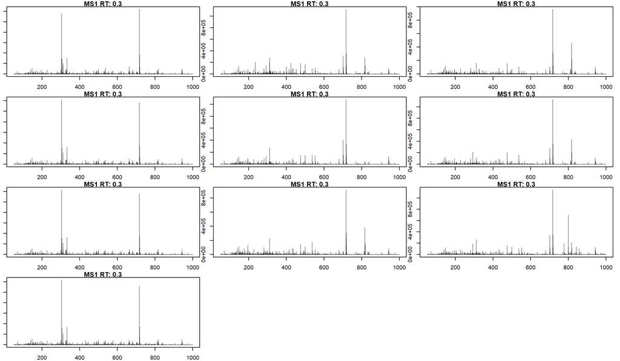

Base peak spectra for the 10 samples of the experiment.

```r
#' Combining all spectra per file into a single spectrum
bps <- spectra(data) |>
    bin(binSize = 0.01) |>
    combineSpectra(f = fromFile(data), intensityFun = max, ppm = 3)

#' Plot the base peak spectra
par(mar = c(2, 1, 1, 1))
plotSpectra(bps)
```

The Base Peak Spectra (BPS) reveal the most prevalent ions present in each of the samples. Here, there is observable overlap in ion content between the files, particularly around 300 *m/z* and 700 *m/z*. There are however also differences between sets of samples. In particular, BPS 1, 4, 7 and 10 (counting row-wise from left to right) seem different than the others. In fact, these 4 BPS are from QC samples, and the remaining 6 from the study samples. The observed differences might be explained by the fact that the QC samples are pools of serum samples from a different cohort, while the study samples represent plasma samples, from a different sample collection.

Next to the visual inspection above, we can also calculate and express the similarity between the BPS with a heatmap. Below we use the `compareSpectra()` function to calculate pairwise similarities between all BPS and use then the `pheatmap()` function from the *pheatmap* package to cluster and visualize this result.

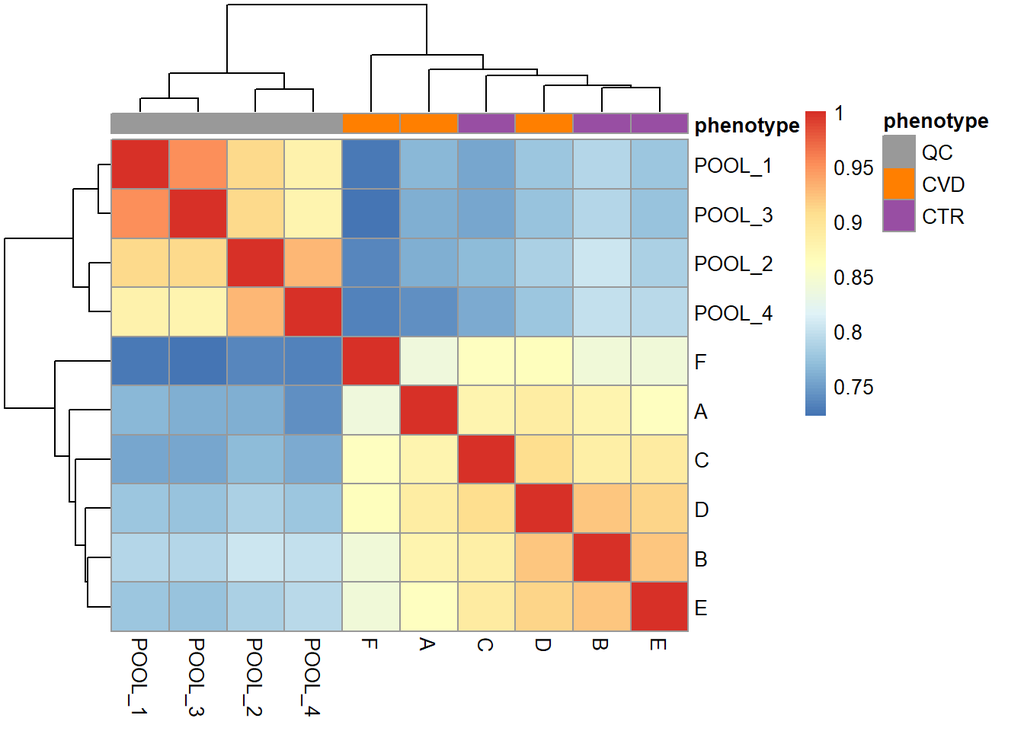

```r
#' Calculate similarities between BPS
sim_matrix <- compareSpectra(bps)

#' Add rownames and colnames
rownames(sim_matrix) <- colnames(sim_matrix) <- sampleData(data)$sample_name
ann <- data.frame(phenotype = sampleData(data)[, "phenotype"])
rownames(ann) <- rownames(sim_matrix)

#' plot the heatmap
pheatmap(sim_matrix, annotation_col = ann,
         annotation_colors = list(phenotype = col_phenotype))
```

We get a first glance at how our different samples distribute in terms of similarity. The heatmap above shows that the QC samples are quite different from the study samples. This is expected as the QC samples are a pool of serum samples from a larger cohort, while the study samples are plasma samples from participants from a different study (and sample collection).

It is also strongly recommended to delve deeper into the data by exploring it in more detail. This can be accomplished by carefully assessing our data and extracting spectra or regions of interest for further examination. Here we will now look at how to extract information for specific spectrum from specific samples.

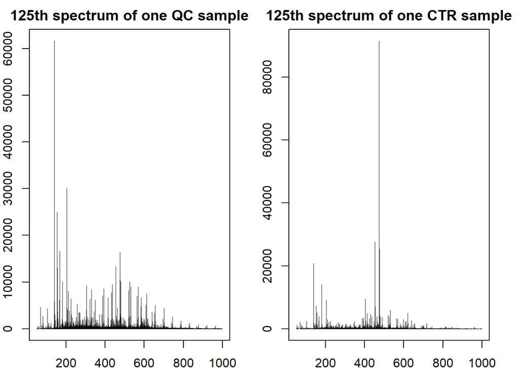

```r
#' Accessing a single spectrum - comparing with QC
par(mfrow = c(1,2), mar = c(2, 2, 2, 2))
spec1 <- spectra(data[1])[125]
spec2 <- spectra(data[3])[125]
plotSpectra(spec1, main = "125th spectrum of one QC sample")
plotSpectra(spec2, main = "125th spectrum of one CTR sample")
```

There is indeed a significant difference in peak distribution and intensity between the QC sample and the CTR sample. This further illustrates the apparent difference in signal between the QC and study samples from this data set. We next compare also a full MS1 spectrum from a CVD and a CTR sample.

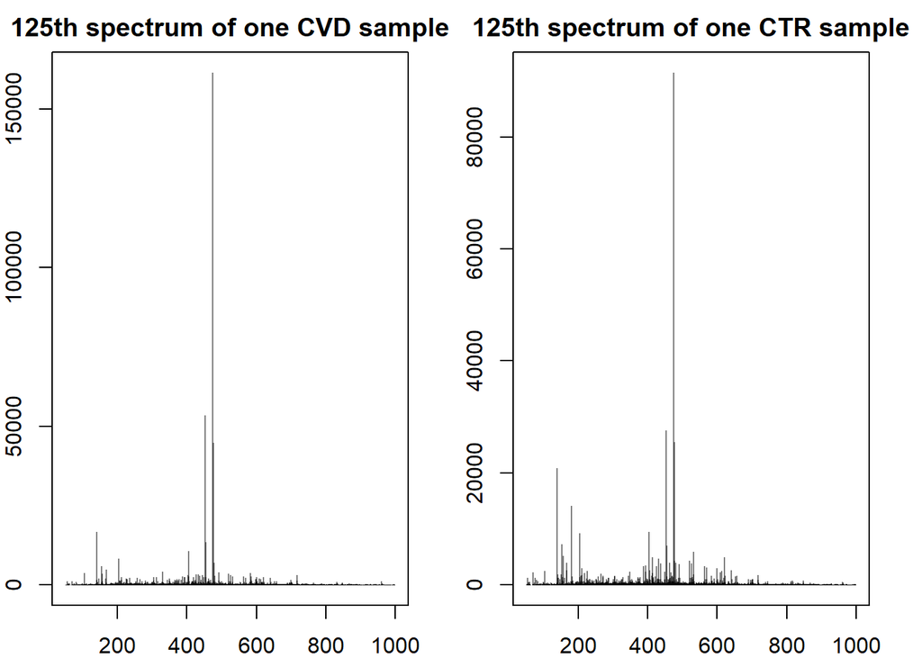

```r
#' Accessing a single spectrum - comparing CVD and CTR
par(mfrow = c(1,2), mar = c(2, 2, 2, 2))
spec1 <- spectra(data[2])[125]
spec2 <- spectra(data[3])[125]
plotSpectra(spec1, main = "125th spectrum of one CVD sample")
plotSpectra(spec2, main = "125th spectrum of one CTR sample")
```

The CTR spectrum above exhibits significant peaks around an *m/z* of 150 - 200 that have a much lower intensity in the CVD sample. To delve into more details about this specific spectrum, a wide range of functions can be employed:

```r
#' Checking its intensity
intensity(spec2)
```

NumericList of length 1 [[1]] 18.3266733266736 45.1666666666667 … 27.1048951048951 34.9020979020979

```r
#' Checking its rtime
rtime(spec2)
```

[1] 34.872

```r
#' Checking its m/z
mz(spec2)
```

NumericList of length 1 [[1]] 51.1677328505635 53.0461968245186 … 999.139446289161 999.315208803072

```r
#' Filtering for a specific  m/z range and viewing in a tabular format
filt_spec <- filterMzRange(spec2,c(50,200))

data.frame(intensity = unlist(intensity(filt_spec)),
           mz = unlist(mz(filt_spec))) |>
  head() |>
  pandoc.table(style = "rmarkdown", caption = "Table 2. Intensity and m/z
               values of the 125th spectrum of one CTR sample.")
```

Table 2. Intensity and m/z values of the 125th spectrum of one CTR sample.

| intensity | mz |
| --- | --- |
| 18.33 | 51.17 |
| 45.17 | 53.05 |
| 23.08 | 53.7 |
| 41.36 | 53.84 |
| 32.87 | 53.88 |
| 1159 | 54.01 |

## Chromatographic Data Visualization

By setting the parameter `aggregationFun = "max"`, we instruct the function to report the maximum signal per spectrum. Conversely, when setting `aggregationFun = "sum"`, it sums up all intensities of a spectrum, thereby creating a Total Ion Chromatogram (TIC).

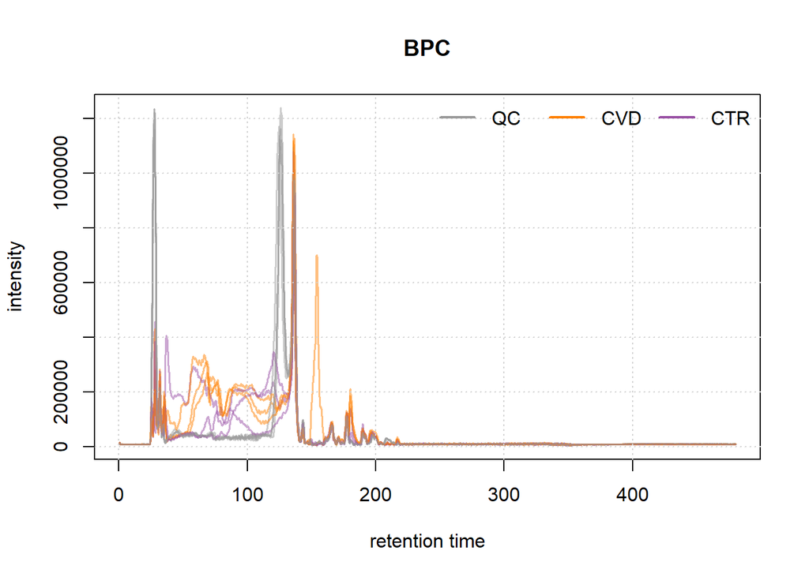

```r
#' Extract and plot BPC for full data
bpc <- chromatogram(data, aggregationFun = "max")

plot(bpc, col = paste0(col_sample, 80), main = "BPC", lwd = 1.5)
grid()
legend("topright", col = col_phenotype,
       legend = names(col_phenotype), lty = 1, lwd = 2, horiz = TRUE, bty = "n")
```

After about 240 seconds no signal seems to be measured. Thus, we below filter the data removing that part as well as the first 10 seconds measured in the LC run.

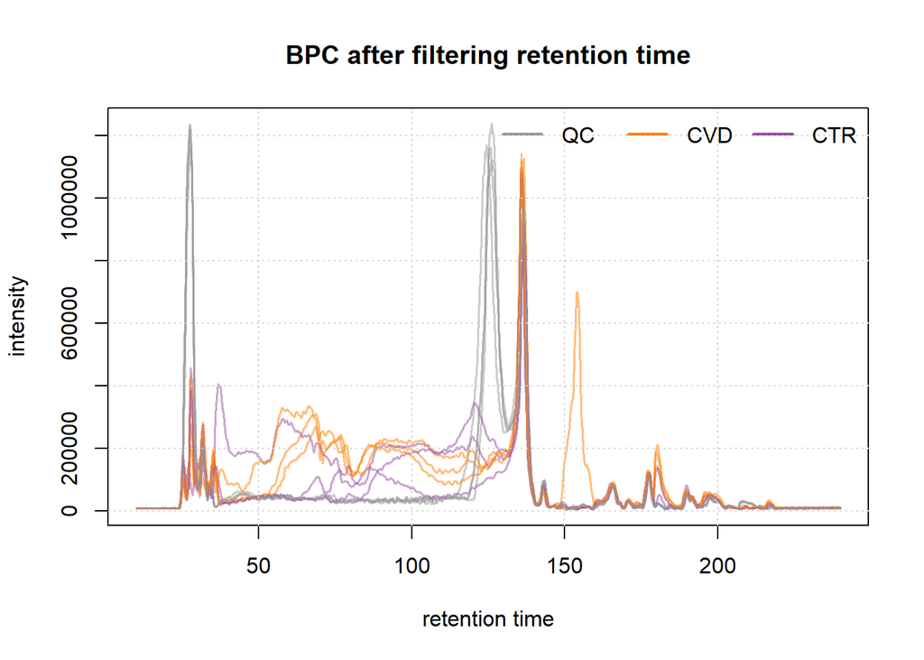

```r
#' Filter the data based on retention time
data <- filterRt(data, c(10, 240))
bpc <- chromatogram(data, aggregationFun = "max")

#' Plot after filtering
plot(bpc, col = paste0(col_sample, 80),
     main = "BPC after filtering retention time", lwd = 1.5)
grid()
legend("topright", col = col_phenotype,
       legend = names(col_phenotype), lty = 1, lwd = 2, horiz = TRUE, bty = "n")
```

Initially, we examined the entire Base Peak Chromatogram (BPC) and subsequently filtered it based on specific retention times. This not only results in a smaller file size but also facilitates a more straightforward interpretation of the BPC.

The final plot illustrates the BPC for each sample colored by phenotype, providing insights on the signal measured along the retention times of each sample. It reveals the points at which compounds eluted from the LC column. In essence, a BPC condenses the three-dimensional LC-MS data (*m/z* by retention time by intensity) into two dimensions (retention time by intensity).

We can also here compare similarities of the BPCs in a heatmap. The retention times will however not be identical between different samples. Thus we *bin* the chromatographic signal per sample along the retention time axis into bins of 2 seconds resulting in data with the same number of bins/data points. We can then calculate pairwise similarities between these data vectors using the `cor()` function and visualize the result using a heatmap.

```r
#' Total ion chromatogram
tic <- chromatogram(data, aggregationFun = "sum") |>
  bin(binSize = 2)

#' Calculate similarity (Pearson correlation) between BPCs
ticmap <- do.call(cbind, lapply(tic, intensity)) |>
  cor()

rownames(ticmap) <- colnames(ticmap) <- sampleData(data)$sample_name
ann <- data.frame(phenotype = sampleData(data)[, "phenotype"])
rownames(ann) <- rownames(ticmap)

#' Plot heatmap
pheatmap(ticmap, annotation_col = ann,
         annotation_colors = list(phenotype = col_phenotype))
```

[output not shown]

Additionally, study samples group into two clusters, cluster *I* containing samples *C* and *F* and cluster *II* with all other samples. Below we plot the TIC of all samples, using a different color for each cluster.

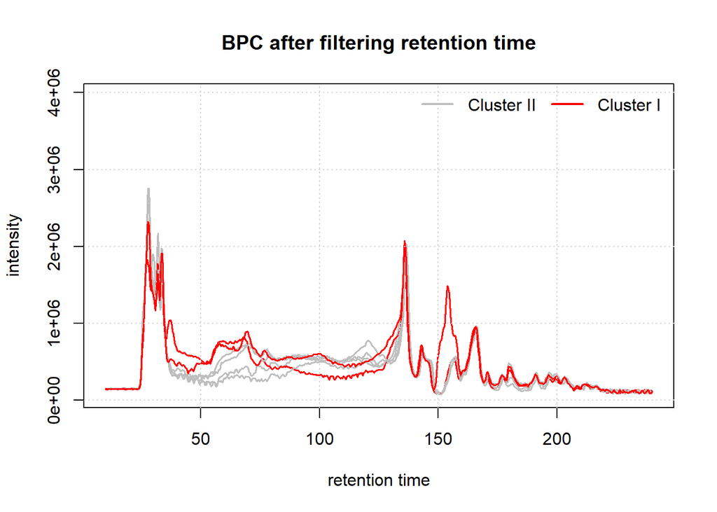

```r
cluster_I_idx <- sampleData(data)$sample_name %in% c("F", "C")
cluster_II_idx <- sampleData(data)$sample_name %in% c("A", "B", "D", "E")

temp_col <- c("grey", "red")
names(temp_col) <- c("Cluster II", "Cluster I")
col <- rep(temp_col[1], length(data))
col[cluster_I_idx] <- temp_col[2]
col[sampleData(data)$phenotype == "QC"] <- NA

data |>
    chromatogram(aggregationFun = "sum") |>
    plot( col = col,
     main = "BPC after filtering retention time", lwd = 1.5)
grid()
legend("topright", col = temp_col,
       legend = names(temp_col), lty = 1, lwd = 2,
       horiz = TRUE, bty = "n")
```

While over and above the TIC of all samples look similar, the samples from cluster I show a different signal in the retention time range from about 40 to 160 seconds. Whether, and how strong this difference will impact the following analysis remains however to be determined.

### Known compounds

Below, we generate Extracted Ion Chromatograms (EIC) for these selected *test ions*. By restricting the MS data to intensities within a restricted, small *m/z* range and a selected retention time window, EICs are expected to contain only signal from a single type of ion. The expected *m/z* and retention times for our set of IS was determined in a different experiment. Additionally, in cases where internal standards are not available, commonly present ions in the sample matrix can serve as suitable alternatives. Ideally, these compounds should be distributed across the entire retention time range of the experiment.

```r
#' Load our list of standard
intern_standard <- read.delim("intern_standard_list.txt")

# Extract EICs for the list
eic_is <- chromatogram(
    data,
    rt = as.matrix(intern_standard[, c("rtmin", "rtmax")]),
    mz = as.matrix(intern_standard[, c("mzmin", "mzmax")]))

#' Add internal standard metadata
fData(eic_is)$mz <- intern_standard$mz
fData(eic_is)$rt <- intern_standard$RT
fData(eic_is)$name <- intern_standard$name
fData(eic_is)$abbreviation <- intern_standard$abbreviation
rownames(eic_is) <- intern_standard$abbreviation

#' Summary of IS information
cpt <- paste("Table 3.Internal standard list with respective m/z and expected",
             "retention time [s].")
fData(eic_is)[, c("name", "mz", "rt")] |>
  as.data.frame() |>
  pandoc.table(style = "rmarkdown", caption = cpt)
```

Table 3.Internal standard list with respective m/z and expected retention time [s]. (continued below)

|  | name | mz |
| --- | --- | --- |
| **carnitine_d3** | Carnitine (D3) | 165.1 |
| **creatinine_methyl_d3** | Creatinine (N-Methhyl_D3) | 117.1 |
| **glucose_d2** | Glucose (6,6-D2) | 205.1 |
| **alanine_13C_15N** | L-Alanine (13C3, 99%; 15N, 99%) | 94.06 |
| **arginine_13C_15N** | L-Arginine HCl (13C6, 99%; 15N4, 99%) | 185.1 |
| **aspartic_13C_15N** | L-Aspartic acid (13C4, 99%; 15N, 99%) | 139.1 |
| **cystine_13C_15N** | L-Cystine (13C6, 99%; 15N2, 99%) | 249 |
| **glutamic_13C_15N** | L-Glutamic acid (13C5, 99%; 15N, 99%) | 154.1 |
| **glycine_13C_15N** | Glycine (13C2, 99%; 15N, 99%) | 79.04 |
| **histidine_13C_15N** | L-Histidine HCl H2O (13C6; 15N3, 99%) | 165.1 |
| **isoleucine_13C_15N** | L-Isoleucine (13C6, 99%; 15N, 99%) | 139.1 |
| **leucine_13C_15N** | L-Leucine (13C6, 99%; 15N, 99%) | 139.1 |
| **lysine_13C_15N** | L-Lysine 2HCl (13C6, 99%; 15N2, 99%) | 155.1 |
| **methionine_13C_15N** | L-Methionine (13C5, 99%; 15N, 99%) | 156.1 |
| **phenylalanine_13C_15N** | L-Phenylalanine (13C9, 99%; 15N, 99%) | 176.1 |
| **proline_13C_15N** | L-Proline (13C5, 99%; 15N, 99%) | 122.1 |
| **serine_13C_15N** | L-Serine (13C3, 99%; 15N, 99%) | 110.1 |
| **threonine_13C_15N** | L-Threonine (13C4, 99%; 15N, 99%) | 125.1 |
| **tyrosine_13C_15N** | L-Tyrosine (13C9, 99%; 15N, 99%) | 192.1 |
| **valine_13C_15N** | L-Valine (13C5, 99%; 15N, 99%) | 124.1 |

|  | rt |
| --- | --- |
| **carnitine_d3** | 61 |
| **creatinine_methyl_d3** | 126 |
| **glucose_d2** | 166 |
| **alanine_13C_15N** | 167 |
| **arginine_13C_15N** | 183 |
| **aspartic_13C_15N** | 179 |
| **cystine_13C_15N** | 209 |
| **glutamic_13C_15N** | 171 |
| **glycine_13C_15N** | 168 |
| **histidine_13C_15N** | 185 |
| **isoleucine_13C_15N** | 154 |
| **leucine_13C_15N** | 151 |
| **lysine_13C_15N** | 184 |
| **methionine_13C_15N** | 161 |
| **phenylalanine_13C_15N** | 153 |
| **proline_13C_15N** | 167 |
| **serine_13C_15N** | 178 |
| **threonine_13C_15N** | 171 |
| **tyrosine_13C_15N** | 166 |
| **valine_13C_15N** | 164 |

We below plot the EICs for isotope labeled cystine and methionine.

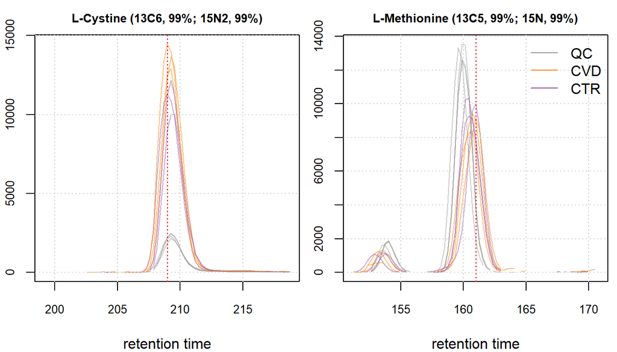

```r
#' Extract the two IS from the chromatogram object.
eic_cystine <- eic_is["cystine_13C_15N"]
eic_met <- eic_is["methionine_13C_15N"]

#' plot both EIC
par(mfrow = c(1, 2), mar = c(4, 2, 2, 0.5))
plot(eic_cystine, main = fData(eic_cystine)$name, cex.axis = 0.8,
     cex.main = 0.8,
     col = paste0(col_sample, 80))
grid()
abline(v = fData(eic_cystine)$rt, col = "red", lty = 3)

plot(eic_met, main = fData(eic_met)$name, cex.axis = 0.8, cex.main = 0.8,
     col = paste0(col_sample, 80))
grid()
abline(v = fData(eic_met)$rt, col = "red", lty = 3)
legend("topright", col = col_phenotype, legend = names(col_phenotype), lty = 1,
       bty = "n")
```

We can observe a clear concentration difference between QCs and study samples for the isotope labeled cystine ion. However, the labeled methionine internal standard exhibits a discernible signal amidst some noise and a noticeable retention time shift between samples.

While the artificially isotope labeled compounds were spiked to the individual samples, there should also be the signal from the endogenous compounds in serum (or plasma) samples. We thus below calculate next the mass and *m/z* of an *[M+H]+* ion of the endogenous cystine from its chemical formula and extract also the EIC from this ion. For calculation of the exact mass and the *m/z* of the selected ion adduct we use the `calculateMass()` and `mass2mz()` functions from the *MetaboCoreUtils* package.

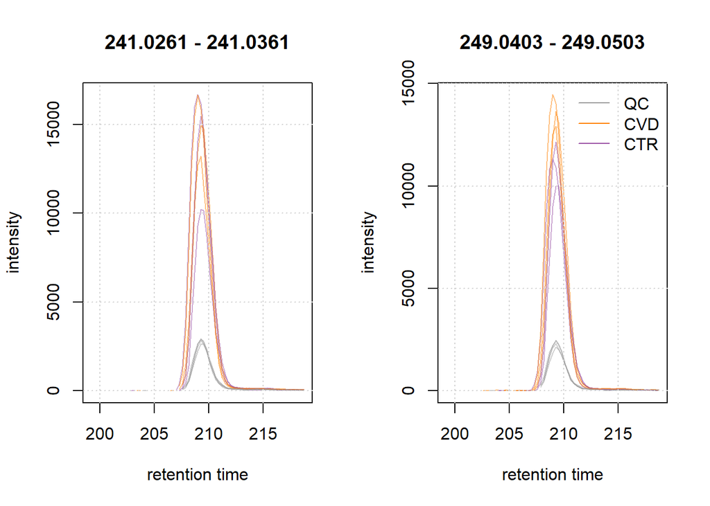

```r
#' extract endogenous cystine mass and EIC and plot.
cysmass <- calculateMass("C6H12N2O4S2")
cys_endo <- mass2mz(cysmass, adduct = "[M+H]+")[, 1]

#' Plot versus spiked
par(mfrow = c(1, 2))
chromatogram(data, mz = cys_endo + c(-0.005, 0.005),
             rt = unlist(fData(eic_cystine)[, c("rtmin", "rtmax")]),
             aggregationFun = "max") |>
    plot(col = paste0(col_sample, 80)) |>
    grid()

plot(eic_cystine, col = paste0(col_sample, 80))
grid()
legend("topright", col = col_phenotype, legend = names(col_phenotype), lty = 1,
       bty = "n")
```

The two cystine EICs above look highly similar (the endogenous shown left, the isotope labeled right in the plot above), if not for the shift in m/z, which arises from the artificial labeling. This shift allows us to discriminate between the endogenous and non-endogenous compound.

# Data preprocessing

Preprocessing stands as the inaugural step in the analysis of untargeted LC-MS or gas chromatography (GC)-MS data. The primary objective of preprocessing is the quantification of signals from ions measured in a sample, addressing any potential retention time drifts between samples, and ensuring alignment of quantified signals across samples within an experiment. The final result of LC-MS data preprocessing is a numeric matrix with abundances of quantified entities in the samples of the experiment.

## Chromatographic peak detection

The initial preprocessing step involves detecting of intensity peaks along the retention time axis, the so called *chromatographic peaks*. To achieve this, we employ the `findChromPeaks()` function within *xcms*. This function supports various algorithms for peak detection, which can be selected and configured with their respective parameter objects, with notable options including:

- `MatchedFilterParam`: Implements peak detection as described in the original xcms article (**smith_xcms:_2006?**).
- `CentWaveParam`: Utilizes continuous wavelet transformation (CWT)-based peak detection (Tautenhahn, Böttcher, and Neumann 2008).
- `MassifquantParam`: Employs a Kalman filter-based peak detection (**conley_massifquant:_2014?**).

The preferred algorithm, in this case, is *CentWave*, known for its effectiveness in handling non-Gaussian shaped chromatographic peaks or peaks with different retention time widths, commonly encountered in HILIC separation.

Below we apply the CentWave algorithm with its default settings on the extracted ion chromatogram for cystine and methionine ions and evaluate its results.

```r
#' Use default Centwave parameter
param <- CentWaveParam()

#' Evaluate for Cystine
cystine_test <- findChromPeaks(eic_cystine, param = param)
chromPeaks(cystine_test)
```

```
##      rt rtmin rtmax into intb maxo sn row column
```

```r
#' Evaluate for Methionine
met_test <- findChromPeaks(eic_met, param = param)
chromPeaks(met_test)
```

```
##      rt rtmin rtmax into intb maxo sn row column
```

While *CentWave* is a highly performant algorithm, it necessitates adaptation to each dataset. This implies that the parameters should be fine-tuned based on the user’s data. The example above serves as a clear motivation for users to familiarize themselves with the various parameters and the need to adapt them to a data set. We will discuss the main parameters that can be easily adjusted to suit the user’s dataset:

- `peakwidth`: Specifies the minimal and maximal expected width of the peaks in the retention time dimension. Highly dependent on the chromatographic settings used.
- `ppm`: The maximal allowed difference of mass peaks’ *m/z* values (in parts-per-million) in consecutive scans to consider them representing signal from the same ion.
- `integrate`: This parameter defines the integration method. Here, we primarily use `integrate = 2` because it integrates also signal of a chromatographic peak’s tail and is considered more accurate by the developers.

To determine `peakwidth`, we recommend that users refer to previous EICs and estimate the range of peak widths they observe in their dataset. Ideally, examining multiple EICs should be the goal. For this dataset, the peak widths appear to be around 2 to 10 seconds. We do not advise on going too wide or too narrow with the `peakwidth` parameter as it can lead to false positives or negatives.

To determine the `ppm`, a deeper analysis of the dataset is needed. It is clarified above that `ppm` depends on the instrument, but users should not necessarily input the vendor-advertised ppm. Here’s how to determine it as accurately as possible:

The following steps involve generating a highly restricted MS area with a single mass peak per spectrum, representing the cystine ion. The *m/z* of these peaks is then extracted, their absolute difference calculated and finally expressed in ppm.

```r
#' Restrict the data to signal from cystine in the first sample
cst <- data[1L] |>
  spectra() |>
  filterRt(rt = c(208, 218)) |>
  filterMzRange(mz = fData(eic_cystine)["cystine_13C_15N", c("mzmin", "mzmax")])

#' Show the number of peaks per m/z filtered spectra
lengths(cst)
```

```
##  [1] 1 1 1 1 1 1 1 1 1 1 1 1 1 1 1 1 1 0 0 0 1 1 1 1 1 1 1 1 1 0 1 1 1 1 1 1
```

```r
#' Calculate the difference in m/z values between scans
mz_diff <- cst |>
    mz() |>
    unlist() |>
    diff() |>
    abs()

#' Express differences in ppm
range(mz_diff * 1e6 / mean(unlist(mz(cst))))
```

```
## [1]  0.08829605 14.82188728
```

We therefore, choose a value close to the maximum within this range for parameter `ppm`.

Now, we perform the chromatographic peak detection process with the adapted settings on our EICs. It is important to note that, to properly estimate background noise, sufficient data points outside the chromatographic peak need to be present. This is generally no problem if peak detection is performed on the full LC-MS data set, but for peak detection on EICs the retention time range of the EIC needs to be sufficiently wide. If the function fails to find a peak in an EIC, the initial troubleshooting step should be to increase this range. Also, the signal-to-noise threshold `snthresh` should in general be reduced for peak detection in EICs, because within the small retention time range usually not enough signal is present to properly estimate the background noise. Finally, in case of too few MS1 data points per peaks, setting CentWave’s advanced parameter `extendLengthMSW` to `TRUE` can help with peak detection.

```r
#' Parameters adapted for chromatographic peak detection on EICs.
param <- CentWaveParam(peakwidth = c(1, 8), ppm = 15, integrate = 2,
                       snthresh = 2)

#' Evaluate on the cystine ion
cystine_test <- findChromPeaks(eic_cystine, param = param)
chromPeaks(cystine_test)
```

```
##            rt   rtmin   rtmax      into      intb      maxo sn row column
##  [1,] 209.251 207.577 212.878  4085.675  2911.376  2157.459  4   1      1
##  [2,] 209.251 206.182 213.995 24625.728 19074.407 12907.487  4   1      2
##  [3,] 209.252 207.020 214.274 19467.836 14594.041  9996.466  4   1      3
##  [4,] 209.251 207.577 212.041  4648.229  3202.617  2458.485  3   1      4
##  [5,] 208.974 206.184 213.159 23801.825 18126.978 11300.289  3   1      5
##  [6,] 209.250 207.018 213.714 25990.327 21036.768 13650.329  5   1      6
##  [7,] 209.252 207.857 212.879  4528.767  3259.039  2445.841  4   1      7
##  [8,] 209.252 207.299 213.995 23119.449 17274.140 12153.410  4   1      8
##  [9,] 208.972 206.740 212.878 28943.188 23436.119 14451.023  4   1      9
## [10,] 209.252 207.578 213.437  4470.552  3065.402  2292.881  4   1     10
```

```r
#' Evaluate on the methionine ion
met_test <- findChromPeaks(eic_met, param = param)
chromPeaks(met_test)
```

```
##            rt   rtmin   rtmax     into     intb      maxo sn row column
##  [1,] 159.867 157.913 162.378 20026.61 14715.42 12555.601  4   1      1
##  [2,] 160.425 157.077 163.215 16827.76 11843.39  8407.699  3   1      2
##  [3,] 160.425 157.356 163.215 18262.45 12881.67  9283.375  3   1      3
##  [4,] 159.588 157.635 161.820 20987.72 15424.25 13327.811  4   1      4
##  [5,] 160.985 156.799 163.217 16601.72 11968.46 10012.396  4   1      5
##  [6,] 160.982 157.634 163.214 17243.24 12389.94  9150.079  4   1      6
##  [7,] 159.867 158.193 162.099 21120.10 16202.05 13531.844  3   1      7
##  [8,] 160.426 157.356 162.937 18937.40 13739.73 10336.000  3   1      8
##  [9,] 160.704 158.472 163.215 17882.21 12299.43  9395.548  3   1      9
## [10,] 160.146 157.914 162.379 20275.80 14279.50 12669.821  3   1     10
```

With the customized parameters, a chromatographic peak was detected in each sample. Below, we use the `plot()` function on the EICs to visualize these results.

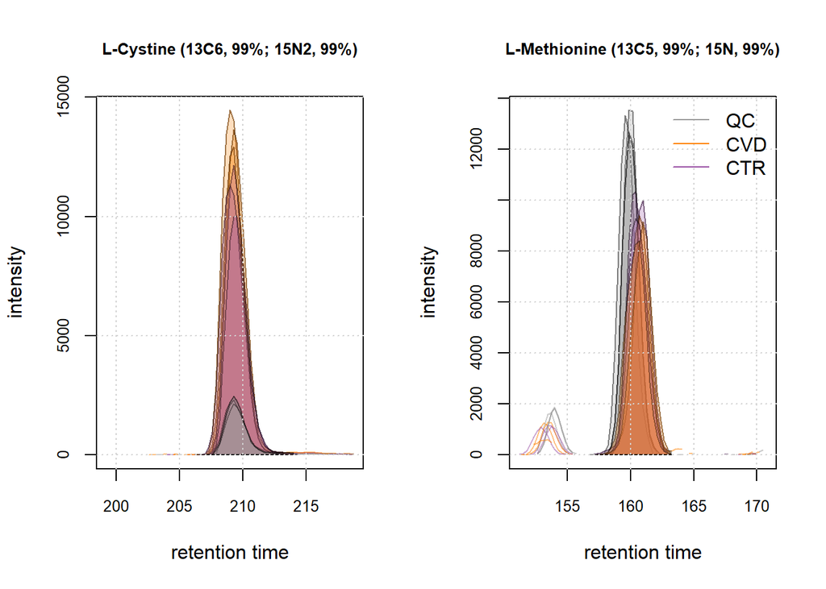

Our custom settings seem thus to be suitable for our dataset. We now proceed and apply them to the entire dataset, extracting EICs again for the same ions to evaluate and confirm that chromatographic peak detection worked as expected. Note that we change the value for parameter `snthresh` to its default, because, as mentioned above, background noise estimation is more reliable when performed on the full data set. Parameter `chunkSize` of `findChromPeaks()` defines the number of data files that are loaded into memory and processed simultaneously. This parameter thus allows to fine-tune the memory demand as well as performance of the chromatographic peak detection step.

```r
#' Using the same settings, but with default snthresh
param <- CentWaveParam(peakwidth = c(1, 8), ppm = 15, integrate = 2)
data <- findChromPeaks(data, param = param, chunkSize = 5)

#' Update EIC internal standard object
eics_is_noprocess <- eic_is
eic_is <- chromatogram(data,
                       rt = as.matrix(intern_standard[, c("rtmin", "rtmax")]),
                       mz = as.matrix(intern_standard[, c("mzmin", "mzmax")]))
fData(eic_is) <- fData(eics_is_noprocess)
```

Below we plot the EICs of the two selected internal standards to evaluate the chromatographic peak detection results.

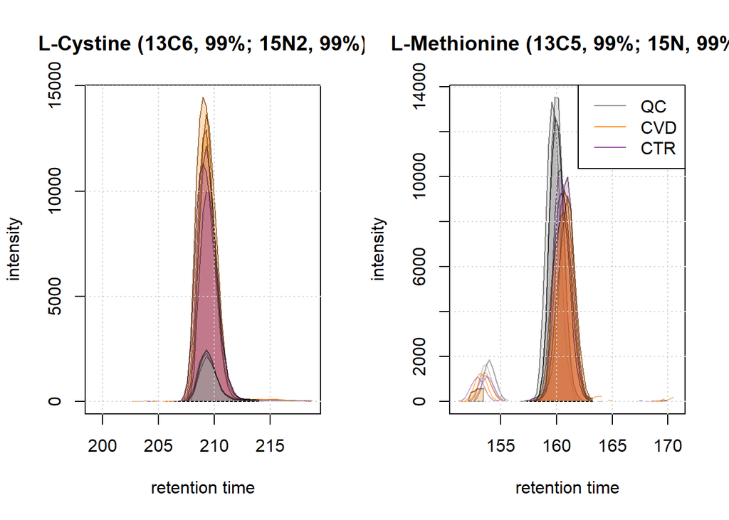

Peaks seems to have been detected properly in all samples for both ions. This indicates that the peak detection process was successful.

### Refine identified chromatographic peaks

The identification of chromatographic peaks using the *CentWave* algorithm can sometimes result in artifacts, such as overlapping or split peaks. To address this issue, the `refineChromPeaks()` function is utilized, in conjunction with the `MergeNeighboringPeaksParam`, which aims at merging such split peaks.

Below we show some examples of *CentWave* peak detection artifacts. These examples are pre-selected to illustrate the necessity of the next step:

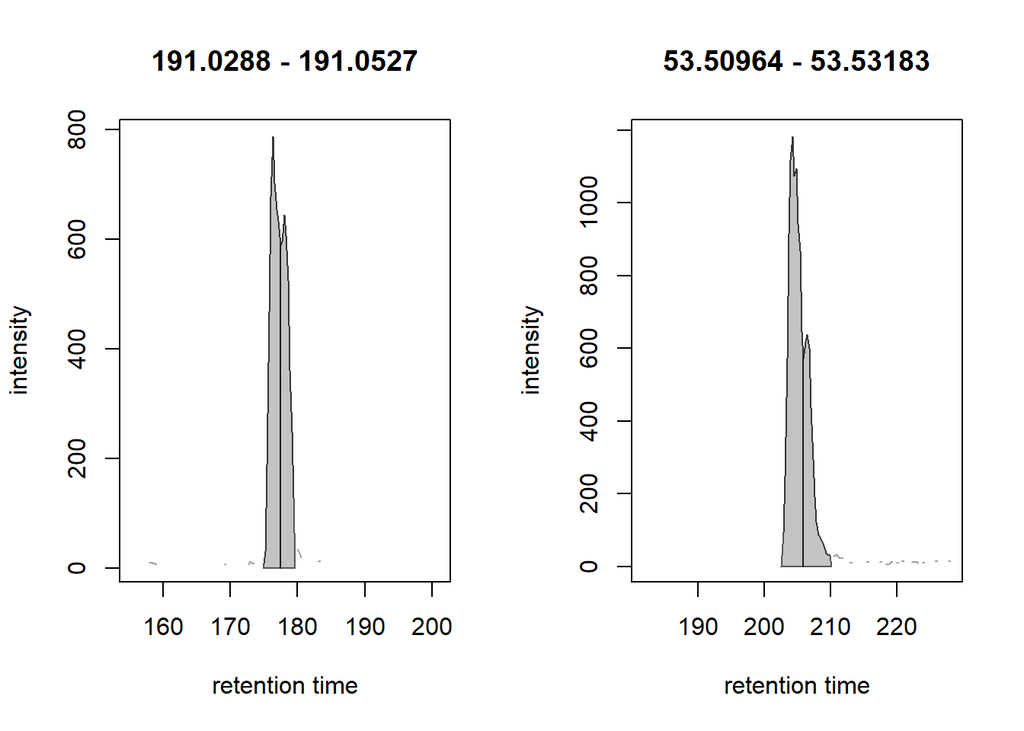

In both cases the signal presumably from a single type of ion was split into two separate chromatographic peaks (indicated by the vertical line). The `MergeNeigboringPeaksParam` allows to combine such split peaks. The parameters for this algorithm are `expandMz`, `expandRt` and `minProp`. `expandMz` and `expandRt` define which chromatographic peaks should be evaluated for merging and `minProp` is used to determine whether candidates are actually merged: chromatographic peaks with overlapping *m/z* ranges (expanded on each side by `expandMz`) and with a distance tail to head in retention time dimension that is less than `2 * expandRt` and for which the signal between them is higher than `minProp` of the apex intensity of the chromatographic peak with the lower intensity are merged.

Parameter `expandRt` is usually set to approximately half the size of the average retention time width used for chromatographic peak detection (in this case 2.5 seconds). Parameter `expandMz` is suggested to be kept relatively small (here at 0.0015) to prevent the merging of isotopes. Also, values for `minProp` should not be too small to avoid merging of closely co-eluting ions such as isomers. We test these settings below on the EICs with the split peaks.

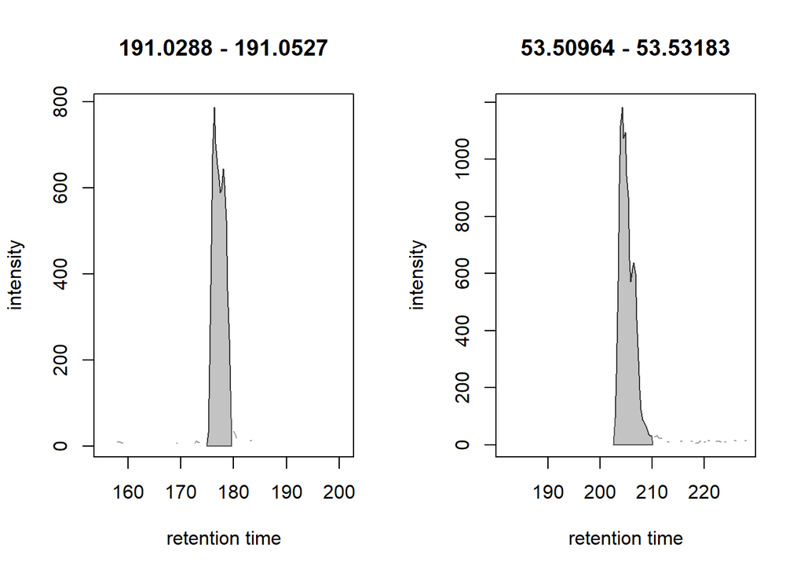

```r
#' set up the parameter
param <- MergeNeighboringPeaksParam(expandRt = 2.5, expandMz = 0.0015,
                                    minProp = 0.75)

#' Perform the peak refinement on the EICs
eics <- refineChromPeaks(eics, param = param)
plot(eics)
```

We can observe that the artificially split peaks have been appropriately merged. Therefore, we next apply these settings to the entire dataset. After peak merging, column `"merged"` in the result object’s `chromPeakData()` data frame can be used to evaluate which chromatographic peaks in the result represent signal from merged, or from the originally identified chromatographic peaks.

```r
#' Apply on whole dataset
data <- refineChromPeaks(data, param = param, chunkSize = 5)
chromPeakData(data)$merged |>
                      table()
```

```
##
## FALSE  TRUE
## 79908  9274
```

Before proceeding with the next preprocessing step it is generally suggested to evaluate the results of the chromatographic peak detection on EICs of e.g. internal standards or other compounds/ions known to be present in the samples.

```r
eics_is_chrompeaks <- eic_is

eic_is <- chromatogram(data,
                       rt = as.matrix(intern_standard[, c("rtmin", "rtmax")]),
                       mz = as.matrix(intern_standard[, c("mzmin", "mzmax")]))
fData(eic_is) <- fData(eics_is_chrompeaks)

eic_cystine <- eic_is["cystine_13C_15N", ]
eic_met <- eic_is["methionine_13C_15N", ]
```

Also evaluating and comparing the number of identified chromatographic peaks in all samples of a data set can help spotting potentially problematic samples. Below we count the number of chromatographic peaks per sample and show these numbers in a table.

```r
#' Count the number of peaks per sample and summarize them in a table.
data.frame(sample_name = sampleData(data)$sample_name,
           peak_count = as.integer(table(chromPeaks(data)[, "sample"]))) |>
    pandoc.table(
        style = "rmarkdown",
        caption = "Table 4.Samples and number of identified chromatographic peaks.")
```

Table 4.Samples and number of identified chromatographic peaks.

| sample_name | peak_count |
| --- | --- |
| POOL_1 | 9287 |
| A | 8986 |
| B | 8738 |
| POOL_2 | 9193 |
| C | 8351 |
| D | 8778 |
| POOL_3 | 9211 |
| E | 8787 |
| F | 8515 |
| POOL_4 | 9336 |

About the same number of chromatographic peaks was identified in the various samples of the data set.

There would be additional options to evaluate chromatographic peak detection results from visualizations such as those created with `plotChromPeaks()` to summaries that could be easily generated with base R commands.

## Retention time alignment

Despite using the same chromatographic settings and conditions there will always be shifts in retention times between samples from an experiment. These will be generally small if samples are measured within the same batch/measurement run, but can be considerable if data of an experiment was acquired across a longer time period.

Below we extract base peak chromatograms from the study’s QC samples and plot them.

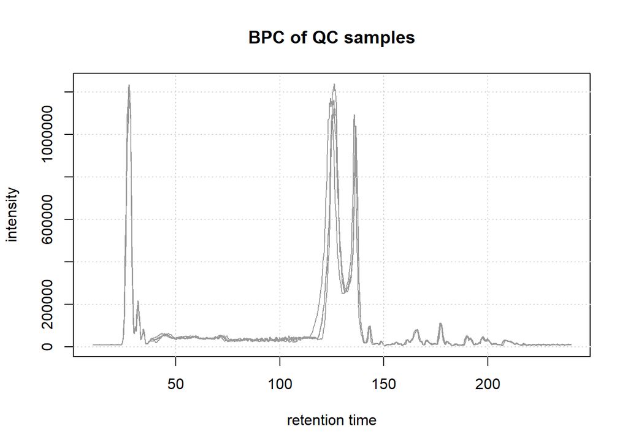

These QC samples representing the same sample (pool) were measured at regular intervals during the measurement run of the experiment and were all measured on the same day. Still, small shifts can be observed, especially between 100 and 150 seconds. To facilitate proper correspondence of signals across samples (and hence definition of the LC-MS features), it is essential to minimize these differences in retention times.

In *xcms* retention time alignment can be performed using the `adjustRtime()` function and one of the available alignments algorithms that can be selected and configured using the respective parameter object. For this example we use the *PeakGroups* method (**smith_xcms:_2006?**) that performs the alignment by minimizing differences in retention times of a set of *anchor peaks* in the different samples. This method requires an initial correspondence analysis to match/group chromatographic peaks across samples from which the algorithm then selects the anchor peaks for the alignment.

For the initial correspondence, we use the *PeakDensity* approach (**smith_xcms:_2006?**) that groups chromatographic peaks with similar *m/z* and retention time into LC-MS features. An LC-MS feature, or in short feature, represents signal from the same type of ion across all samples of a data set. The parameters for this algorithm, that can be configured using the `PeakDensityParam` object, are `sampleGroups`, `minFraction`, `binSize`, `ppm` and `bw`. `binSize`, `ppm` and `bw` allow to specify how similar the chromatographic peaks’ *m/z* and retention time values need to be to consider them for grouping into a feature. Here `binSize` and `ppm` define the required similarity of *m/z* values. Within each *m/z* bin (defined by `binSize` and `ppm`) areas along the retention time axis with a high chromatographic peak density (considering all peaks in all samples) are identified, and chromatographic peaks within these regions are considered for grouping into a feature. High density areas are identified using the base R `density()` function, for which `bw` is a parameter: higher values define wider retention time areas, lower values require chromatographic peaks to have more similar retention times. Whether such candidate peaks get grouped into a feature depends also on parameters `sampleGroups` and `minFraction`: `sampleGroups` should provide, for each sample, the sample group it belongs to, and `minFraction` is expected to be a value between 0 and 1 defining the proportion of samples within at least one of the sample groups (defined with `sampleGroups`) in which a chromatographic peaks was detected to group them into a feature.

For the initial correspondence, parameters don’t need to be fully optimized. Selection of data set-specific parameter values is described in more detail in the following section. For our data set, we use small values for `binSize` and `ppm` and, importantly, also for parameter `bw`, since for our data set an ultra high performance (UHP) LC setup was used. For `minFraction` we use a high value (0.9) to ensure only features are defined for chromatographic peaks present in almost all samples of one sample group (which can then be used as anchor peaks for the actual alignment). We will base the alignment later on QC samples only and hence define for `sampleGroups` a binary variable grouping samples either into a study, or QC group.

```r
# Initial correspondence analysis
param <- PeakDensityParam(sampleGroups = sampleData(data)$phenotype == "QC",
                          minFraction = 0.9,
                          binSize = 0.01, ppm = 10,
                          bw = 2)
data <- groupChromPeaks(data, param = param)
```

*PeakGroups*-based alignment can next be performed using the `adjustRtime()` function with a `PeakGroupsParam` parameter object. The parameters for this algorithm are:

- `subsetAdjust` and `subset`: Allows for subset alignment. Here we base the retention alignment on the QC samples, i.e., retention time shifts will be estimated based on these repeatedly measured samples. The resulting adjustment is then applied to the entire data. For data sets in which QC samples (e.g. sample pools) are measured repeatedly, we strongly suggest to use this method. Note also that for subset-based alignment the samples should be ordered by injection index (i.e., in the order in which they were measured during the measurement run).
- `minFraction`: a value between 0 and 1 defining the proportion of samples (of the full data set, or the data subset defined with `subset`) in which a chromatographic peak had to be identified to use it as *anchor peak*. This is in contrast to the `PeakDensityParam` where this parameter was used to define a proportion within a sample group.
- `span`: The *PeakGroups* method allows, depending on the data, to adjust regions along the retention time axis differently. To enable such local alignments the *LOESS* function is used and this parameter defines the degree of smoothing of this function. Generally, values between 0.4 and 0.6 are used, however, it is suggested to evaluate alignment results and eventually adapt parameters if the result was not satisfactory.

Below we perform the alignment of our data set based on retention times of anchor peaks defined in the subset of QC samples. QC samples, e.g. a pool of the study samples, repeatedly measured within an experiment are ideal for alignment, because the same ions are expected to be quantified in all of them enabling easier and more reliable definition of anchor peaks. Despite having external QCs in our data set, we still use the subset-based alignment assuming retention time shifts to be independent of the different sample matrix (human serum or plasma).

```r
#' Define parameters of choice
subset <- which(sampleData(data)$phenotype == "QC")
param <- PeakGroupsParam(minFraction = 0.9, extraPeaks = 50, span = 0.5,
                         subsetAdjust = "average",
                         subset = subset)

#' Perform the alignment
data <- adjustRtime(data, param = param)
```

Alignment adjusted the retention times of all spectra in the data set, as well as the retention times of all identified chromatographic peaks. Note that it would also be possible to manually specify anchor peaks, respectively their retention times or to align a data set against an external, reference, data set. More information is provided in the vignettes of the *xcms* package.

Once the alignment has been performed, the user should evaluate the results using the `plotAdjustedRtime()` function. This function visualizes the difference between adjusted and raw retention time for each sample on the y-axis along the adjusted retention time on the x-axis. Dot points represent the position of the used anchor peak along the retention time axis. For optimal alignment in all areas along the retention time axis, these anchor peaks should be scattered all over the retention time dimension.

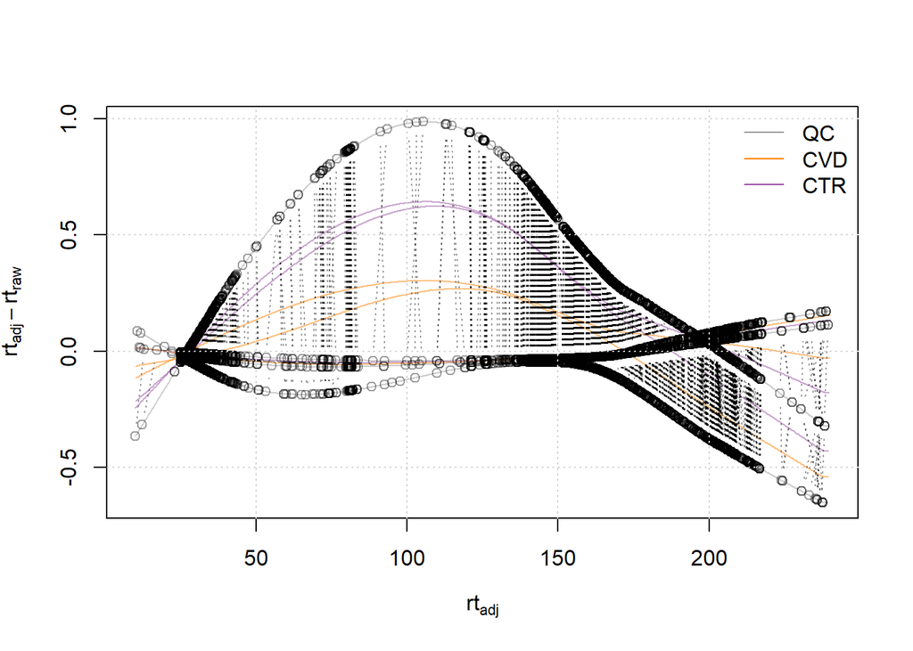

```r
#' Visualize alignment results
plotAdjustedRtime(data, col = paste0(col_sample, 80), peakGroupsPch = 1)
grid()
legend("topright", col = col_phenotype,
       legend = names(col_phenotype), lty = 1, bty = "n")
```

All samples from the present data set were measured within the same measurement run, thus only small retention time shifts were present. Therefore, only little adjustments needed to be performed (shifts of at maximum 1 second as can be seen in the plot above). Generally, the magnitude of adjustment seen in such plots should match the expectation from the analyst.

We can also compare the BPC before and after alignment. To get the original data, i.e. the raw retention times, we can use the `dropAdjustedRtime()` function:

```r
#' Get data before alignment
data_raw <- dropAdjustedRtime(data)

#' Apply the adjusted retention time to our dataset
data <- applyAdjustedRtime(data)
```

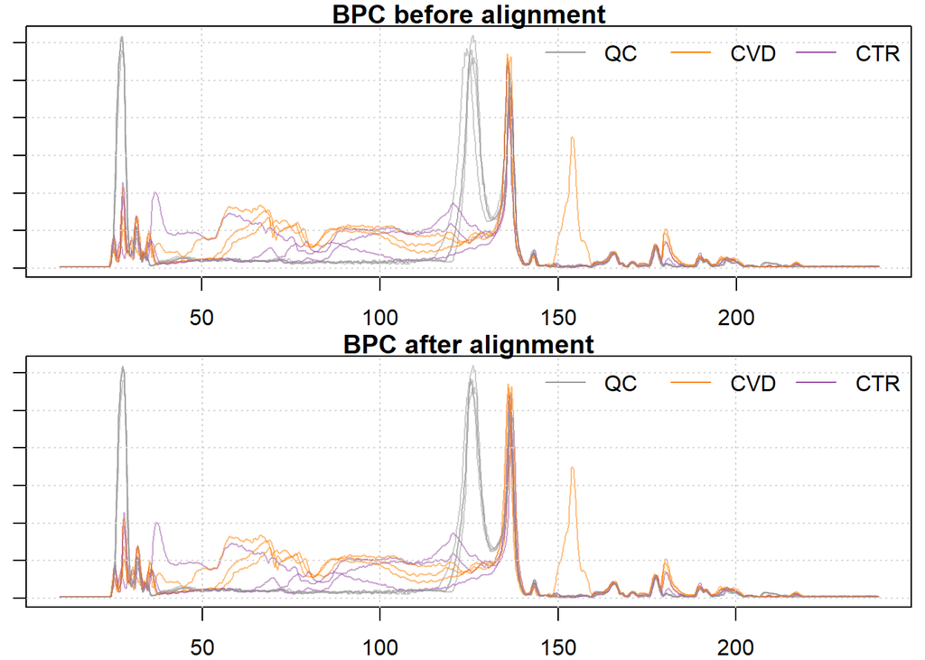

```r
#' Plot the BPC before and after alignment
par(mfrow = c(2, 1), mar = c(2, 1, 1, 0.5))
chromatogram(data_raw, aggregationFun = "max", chromPeaks = "none") |>
    plot(main = "BPC before alignment", col = paste0(col_sample, 80))
grid()
legend("topright", col = col_phenotype,
       legend = names(col_phenotype), lty = 1, bty = "n", horiz = TRUE)

chromatogram(data, aggregationFun = "max", chromPeaks = "none") |>
    plot(main = "BPC after alignment",
         col = paste0(col_sample, 80))
grid()
legend("topright", col = col_phenotype,
       legend = names(col_phenotype), lty = 1, bty = "n", horiz = TRUE)
```

The largest shift can be observed in the retention time range from 120 to 130s. Apart from that retention time range, only little changes can be observed.

We next evaluate the impact of the alignment on the EICs of the selected internal standards. We thus below first extract the ion chromatograms after alignment.

```r
#' Store the EICs before alignment
eics_is_refined <- eic_is

#' Update the EICs
eic_is <- chromatogram(data,
                       rt = as.matrix(intern_standard[, c("rtmin", "rtmax")]),
                       mz = as.matrix(intern_standard[, c("mzmin", "mzmax")]))
fData(eic_is) <- fData(eics_is_refined)

#' Extract the EICs for the test ions
eic_cystine <- eic_is["cystine_13C_15N"]
eic_met <- eic_is["methionine_13C_15N"]
```

We can now evaluate the alignment effect in our test ions. We will plot the EICs before and after alignment for both the isotope labeled cystine and methionine.

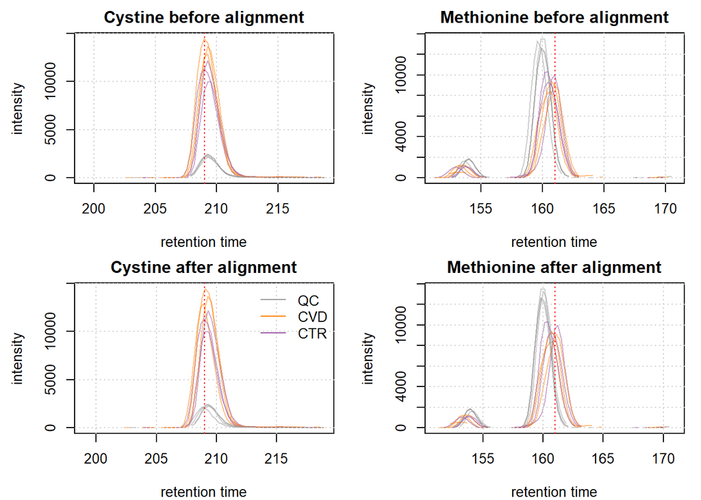

```r
par(mfrow = c(2, 2), mar = c(4, 4.5, 2, 1))

old_eic_cystine <- eics_is_refined["cystine_13C_15N"]
plot(old_eic_cystine, main = "Cystine before alignment", peakType = "none",
     col = paste0(col_sample, 80))
grid()
abline(v = intern_standard["cystine_13C_15N", "RT"], col = "red", lty = 3)

old_eic_met <- eics_is_refined["methionine_13C_15N"]
plot(old_eic_met, main = "Methionine before alignment",
     peakType = "none", col = paste0(col_sample, 80))
grid()
abline(v = intern_standard["methionine_13C_15N", "RT"], col = "red", lty = 3)

plot(eic_cystine, main = "Cystine after alignment", peakType = "none",
     col = paste0(col_sample, 80))
grid()
abline(v = intern_standard["cystine_13C_15N", "RT"], col = "red", lty = 3)
legend("topright", col = col_phenotype,
       legend = names(col_phenotype), lty = 1, bty = "n")

plot(eic_met, main = "Methionine after alignment",
     peakType = "none", col = paste0(col_sample, 80))
grid()
abline(v = intern_standard["methionine_13C_15N", "RT"], col = "red", lty = 3)
```

The non_endogenous cystine ion was already well aligned so the difference is minimal. The methionine ion, however, shows an improvement in alignment.

In addition to a visual inspection of the results, we next also evaluate the impact of the alignment by comparing the variance in retention times for internal standards before and after alignment. To this end we need to first identify chromatographic peaks in each sample with an *m/z* and retention time close to the expected values for each internal standard. For this we use the `matchValues()` function from the *MetaboAnnotation* package (Rainer et al. 2022) using the `MzRtParam` method to identify all chromatographic peaks with similar *m/z* (+/- 50 ppm) and retention time (+/- 10 seconds) to the internal standard’s values. We perform this matching separate for each sample and select for each internal standard, in each sample, using the `filterMatches()` and `SingleMatchParam`, the chromatographic peak with the highest intensity.

```r
#' Extract the matrix with all chromatographic peaks and add a column
#' with the ID of the chromatographic peak
chrom_peaks <- chromPeaks(data) |> as.data.frame()
chrom_peaks$peak_id <- rownames(chrom_peaks)

#' Define the parameters for the matching and filtering of the matches
p_1 <- MzRtParam(ppm = 50, toleranceRt = 10)
p_2 <- SingleMatchParam(duplicates = "top_ranked", column = "target_maxo",
                        decreasing = TRUE)

#' Iterate over samples and identify for each the chromatographic peaks
#' with similar m/z and retention time than the onse from the internal
#' standard, and extract among them the ID of the peaks with the
#' highest intensity.
intern_standard_peaks <- lapply(seq_along(data), function(i) {
    tmp <- chrom_peaks[chrom_peaks[, "sample"] == i, , drop = FALSE]
    mtch <- matchValues(intern_standard, tmp,
                        mzColname = c("mz", "mz"),
                        rtColname = c("RT", "rt"),
                        param = p_1)
    mtch <- filterMatches(mtch, p_2)
    mtch$target_peak_id
}) |>
    do.call(what = cbind)
```

We have now for each internal standard the ID of the chromatographic peak in each sample that most likely represents signal from that ion. We can now extract the retention times for these chromatographic peaks before and after alignment.

```r
#' Define the index of the selected chromatographic peaks in the
#' full chromPeaks matrix
idx <- match(intern_standard_peaks, rownames(chromPeaks(data)))

#' Extract the raw retention times for these
rt_raw <- chromPeaks(data_raw)[idx, "rt"] |>
    matrix(ncol = length(data_raw))

#' Extract the adjusted retention times for these
rt_adj <- chromPeaks(data)[idx, "rt"] |>
    matrix(ncol = length(data_raw))
```

We can now evaluate the impact of the alignment on the retention times of internal standards across the full data set

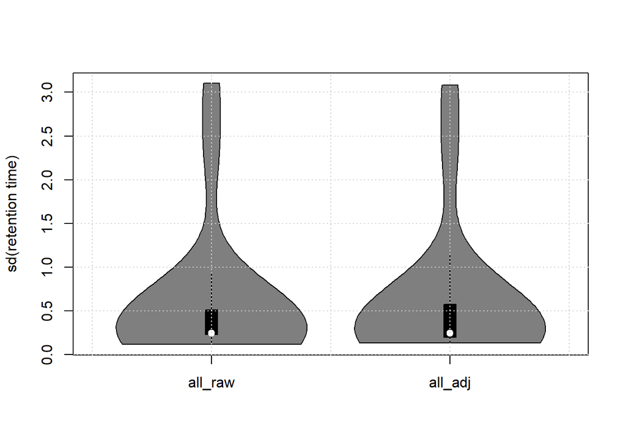

```r
list(all_raw = rowSds(rt_raw, na.rm = TRUE),
     all_adj = rowSds(rt_adj, na.rm = TRUE)
     ) |>
    vioplot(ylab = "sd(retention time)")
grid()
```

## Correspondence

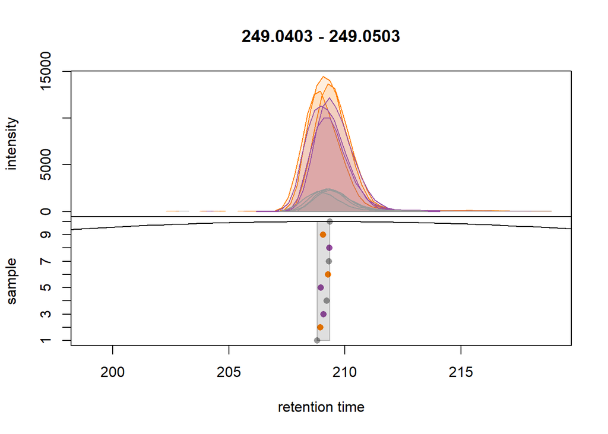

```r
#' Default parameter for the grouping and apply them to the test ions BPC
param <- PeakDensityParam(sampleGroups = sampleData(data)$phenotype, bw = 30)

plotChromPeakDensity(
    eic_cystine, param = param,
    col = paste0(col_sample, "80"),
    peakCol = col_sample[chromPeaks(eic_cystine)[, "sample"]],
    peakBg = paste0(col_sample[chromPeaks(eic_cystine)[, "sample"]], 20),
    peakPch = 16)
```

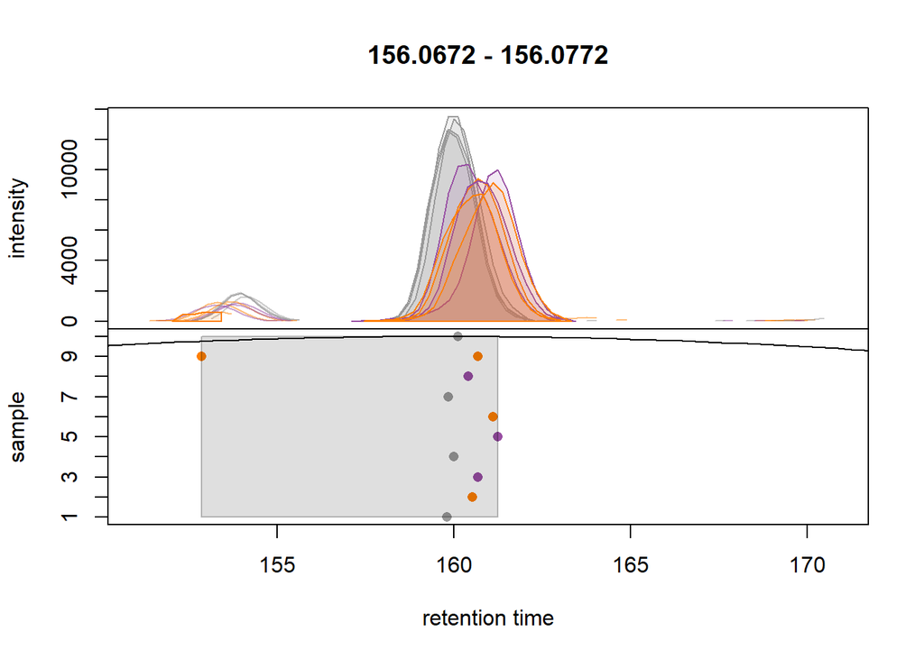

```r
plotChromPeakDensity(eic_met, param = param,
    col = paste0(col_sample, "80"),
    peakCol = col_sample[chromPeaks(eic_met)[, "sample"]],
    peakBg = paste0(col_sample[chromPeaks(eic_met)[, "sample"]], 20),
    peakPch = 16)
```

For this method, it’s crucial to understand that grouping depends on the smoothness of the density curve (shown as a black line in the lower panel of the plot) that can be configured with the parameter `bw`. As seen above, the smoothness is too high to properly group our features. When looking at the default parameters, we can observe that indeed, the `bw` parameter is set to `bw = 30`, which is too high for modern UHPLC-MS setups. We reduce the value of this parameter to 1.8 and evaluate its impact.

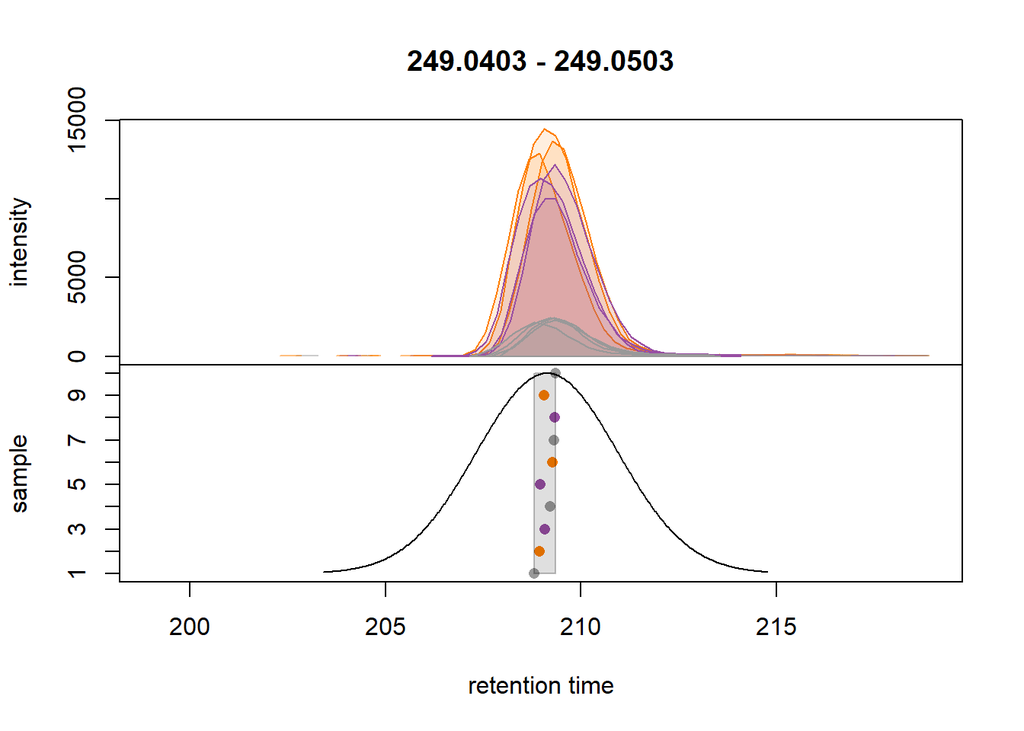

```r
#' Updating parameters
param <- PeakDensityParam(sampleGroups = sampleData(data)$phenotype, bw = 1.8)

plotChromPeakDensity(
    eic_cystine, param = param,
    col = paste0(col_sample, "80"),
    peakCol = col_sample[chromPeaks(eic_cystine)[, "sample"]],
    peakBg = paste0(col_sample[chromPeaks(eic_cystine)[, "sample"]], 20),
    peakPch = 16)
```

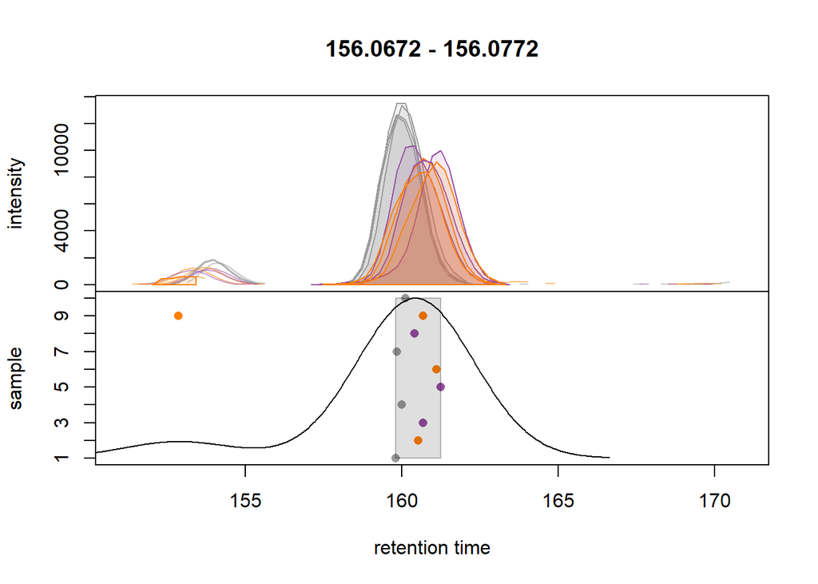

```r
plotChromPeakDensity(eic_met, param = param,
    col = paste0(col_sample, "80"),
    peakCol = col_sample[chromPeaks(eic_met)[, "sample"]],
    peakBg = paste0(col_sample[chromPeaks(eic_met)[, "sample"]], 20),
    peakPch = 16)
```

We can observe that the peaks are now grouped more accurately into a single feature for each test ion. The other important parameters are `binSize` and `ppm` which allow to configure the required similarity of *m/z* values of the chromatographic peaks to consider them for grouping. Our data was generated on a high resolution MS instrument and we thus select a low value for `binSize`. Also, for TOF instruments it is suggested to use a value for `ppm` that is larger than 0 to accommodate the higher measurement error of the instrument for larger *m/z* values. Finally, we set `minFraction = 0.75` hence defining features only if in at least 75% of samples of one of the sample groups a chromatographic peak was identified. For sample groups we use the information available in our `sampleData`’s `"phenotype"` column.

```r
#' Define the settings for the.
param <- PeakDensityParam(sampleGroups = sampleData(data)$phenotype,
                          minFraction = 0.75, binSize = 0.01, ppm = 10,
                          bw = 1.8)

#' Apply to whole data
data <- groupChromPeaks(data, param = param)
```

After correspondence analysis it is suggested to evaluate the results again for selected EICs. Below we extract signal for an *m/z* similar to that of the isotope labeled methionine for a larger retention time range. Importantly, to show the actual correspondence results, we set `simulate = FALSE` for the `plotChromPeakDensity()` function.

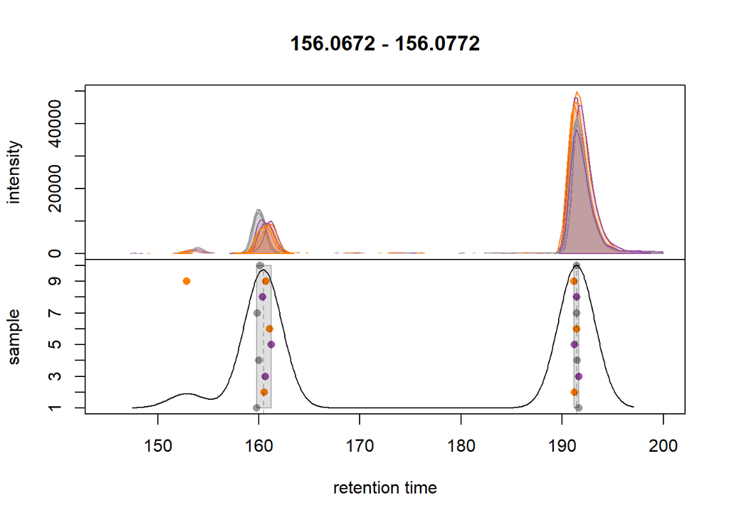

```r
#' Extract chromatogram for an m/z similar to the one of the labeled methionine
chr_test <- chromatogram(data,
                         mz = as.matrix(intern_standard["methionine_13C_15N",
                                                        c("mzmin", "mzmax")]),
                         rt = c(145, 200),
                         aggregationFun = "max")
plotChromPeakDensity(
    chr_test, simulate = FALSE,
    col = paste0(col_sample, "80"),
    peakCol = col_sample[chromPeaks(chr_test)[, "sample"]],
    peakBg = paste0(col_sample[chromPeaks(chr_test)[, "sample"]], 20),
    peakPch = 16)
```

Indeed, signal from the two different ions were now grouped into separate features. Generally, correspondence results should be evaluated on more such extracted chromatograms.

Another interesting information to look a the the distribution of these features along the retention time axis.

```r
# Bin features per RT slices
vc <- featureDefinitions(data)$rtmed
breaks <- seq(0, max(vc, na.rm = TRUE) + 1, length.out = 15) |>
    round(0)
cuts <- cut(vc, breaks = breaks, include.lowest = TRUE)

table(cuts) |>
  pandoc.table(
      style = "rmarkdown",
      caption = "Table 5.Distribution of features along the retention time axis (in seconds.")
```

Table 5.Distribution of features along the retention time axis (in seconds. (continued below)

| [0,17] | (17,34] | (34,51] | (51,68] | (68,86] | (86,103] | (103,120] |
| --- | --- | --- | --- | --- | --- | --- |
| 15 | 2608 | 649 | 24 | 132 | 11 | 15 |

Table continues below

| (120,137] | (137,154] | (154,171] | (171,188] | (188,205] | (205,222] |
| --- | --- | --- | --- | --- | --- |
| 105 | 1441 | 2202 | 410 | 869 | 554 |

| (222,240] |
| --- |
| 33 |

The results from the correspondence analysis are now stored, along with the results from the other preprocessing steps, within our `XcmsExperiment` result object. The correspondence results, i.e., the definition of the LC-MS features, can be extracted using the `featureDefinitions()` function.

```r
#' Definition of the features
featureDefinitions(data) |>
  head()
```

```
##           mzmed    mzmin    mzmax    rtmed    rtmin    rtmax npeaks CTR CVD QC
## FT0001 50.98979 50.98949 50.99038 203.6001 203.1181 204.2331      8   1   3  4
## FT0002 51.05904 51.05880 51.05941 191.1675 190.8787 191.5050      9   2   3  4
## FT0003 51.98657 51.98631 51.98699 203.1467 202.6406 203.6710      7   0   3  4
## FT0004 53.02036 53.02009 53.02043 203.2343 202.5652 204.0901     10   3   3  4
## FT0005 53.52080 53.52051 53.52102 203.1936 202.8490 204.0901     10   3   3  4
## FT0006 54.01007 54.00988 54.01015 159.2816 158.8499 159.4484      6   1   3  2
##             peakidx ms_level
## FT0001 7702, 16....        1
## FT0002 7176, 16....        1
## FT0003 7680, 17....        1
## FT0004 7763, 17....        1
## FT0005 8353, 17....        1
## FT0006 5800, 15....        1
```

This data frame provides the average *m/z* and retention time (in columns `"mzmed"` and `"rtmed"`) that characterize a LC-MS feature. Column, `"peakidx"` contains the indices of all chromatographic peaks that were assigned to that feature. The actual abundances for these features, which represent also the final preprocessing results, can be extracted with the `featureValues()` function:

```r
#' Extract feature abundances
featureValues(data, method = "sum") |>
    head()
```

```
##        MS_QC_POOL_1_POS.mzML MS_A_POS.mzML MS_B_POS.mzML MS_QC_POOL_2_POS.mzML
## FT0001              421.6162      689.2422            NA              481.7436
## FT0002              710.8078      875.9192            NA              693.6997
## FT0003              445.5711      613.4410            NA              497.8866
## FT0004            16994.5260    24605.7340     19766.707            17808.0933
## FT0005             3284.2664     4526.0531      3521.822             3379.8909
## FT0006            10681.7476    10009.6602            NA            10800.5449
##        MS_C_POS.mzML MS_D_POS.mzML MS_QC_POOL_3_POS.mzML MS_E_POS.mzML
## FT0001            NA      635.2732              439.6086      570.5849
## FT0002      781.2416      648.4344              700.9716     1054.0207
## FT0003            NA      634.9370              449.0933            NA
## FT0004    22780.6683    22873.1061            16965.7762    23432.1252
## FT0005     4396.0762     4317.7734             3270.5290     4533.8667
## FT0006            NA     7296.4262                    NA     9236.9799
##        MS_F_POS.mzML MS_QC_POOL_4_POS.mzML
## FT0001      579.9360              437.0340
## FT0002      534.4577              711.0361
## FT0003      461.0465              232.1075
## FT0004    22198.4607            16796.4497
## FT0005     4161.0132             3142.2268
## FT0006     6817.8785                    NA
```

We can note that some features (e.g. F00003 and F00006) have missing values in some samples. This is expected to a certain degree as not in all samples features, respectively their ions, need to be present. We will address this in the next section.

## Gap filling

The previously observed missing values (*NA*) could be attributed to various reasons. Even if they represent a genuinely missing value, indicating that an ion (feature) is truly not present in a particular sample, it could also be a result of a failure in the preceding chromatographic peak detection step. It is crucial to be able to recover missing values of the latter category as much as possible to reduce the eventual need for data imputation. We next examine how prevalent missing values are in our present dataset:

```r
#' Percentage of missing values
sum(is.na(featureValues(data))) /
    length(featureValues(data)) * 100
```

```
## [1] 26.41597
```

We can observe a substantial number of missing values values in our dataset.

Now, let’s delve into the process of *gap-filling*. We first evaluate some example features for which a chromatographic peak was only detected in some samples:

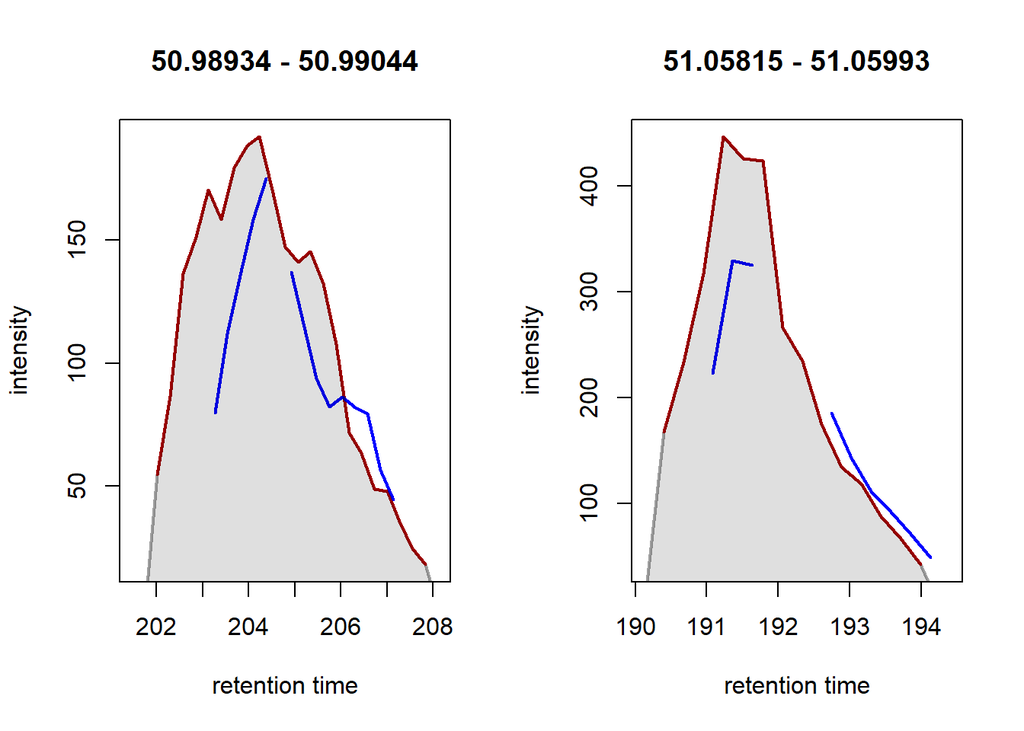

```r
ftidx <- which(is.na(rowSums(featureValues(data))))
fts <- rownames(featureDefinitions(data))[ftidx]
farea <- featureArea(data, features = fts[1:2])

chromatogram(data[c(2, 3)],
             rt = farea[, c("rtmin", "rtmax")],
             mz = farea[, c("mzmin", "mzmax")]) |>
    plot(col = c("red", "blue"), lwd = 2)
```

In both instances, a chromatographic peak was only identified in one of the two selected samples (red line), which no peak was detected in the blue labeled sample and hence a missing value is reported for this feature in that particular samples. Also, in both cases, signal was measured in both samples, thus, reporting a missing values would not be correct in this case. The signal for this feature is, particularly in the blue labeled sample, is very low and sketchy. That is also the most likely reason peak detection failed. To rescue signal in such cases, the `fillChromPeaks()` function can be used with the `ChromPeakAreaParam` approach. This method defines for each feature, based on the detected peaks, the *m/z* - retention time area in which signal for the respective ion is expected, and integrates, in samples with missing values for that feature, all intensities within the area. This is then reported as feature abundance. Below we apply this method using the default parameters.

```r
#' Fill in the missing values in the whole dataset
data <- fillChromPeaks(data, param = ChromPeakAreaParam(), chunkSize = 5)

#' Percentage of missing values after gap-filling
sum(is.na(featureValues(data))) /
    length(featureValues(data)) * 100
```

```
## [1] 5.155492
```

With `fillChromPeaks()` we could thus rescue most of the missing data in the data set. Note that, even if in a sample no ion would be present, in the worst case noise would be integrated, which is expected to be much lower than actual chromatographic peak signal. Let’s look at our previously missing values again:

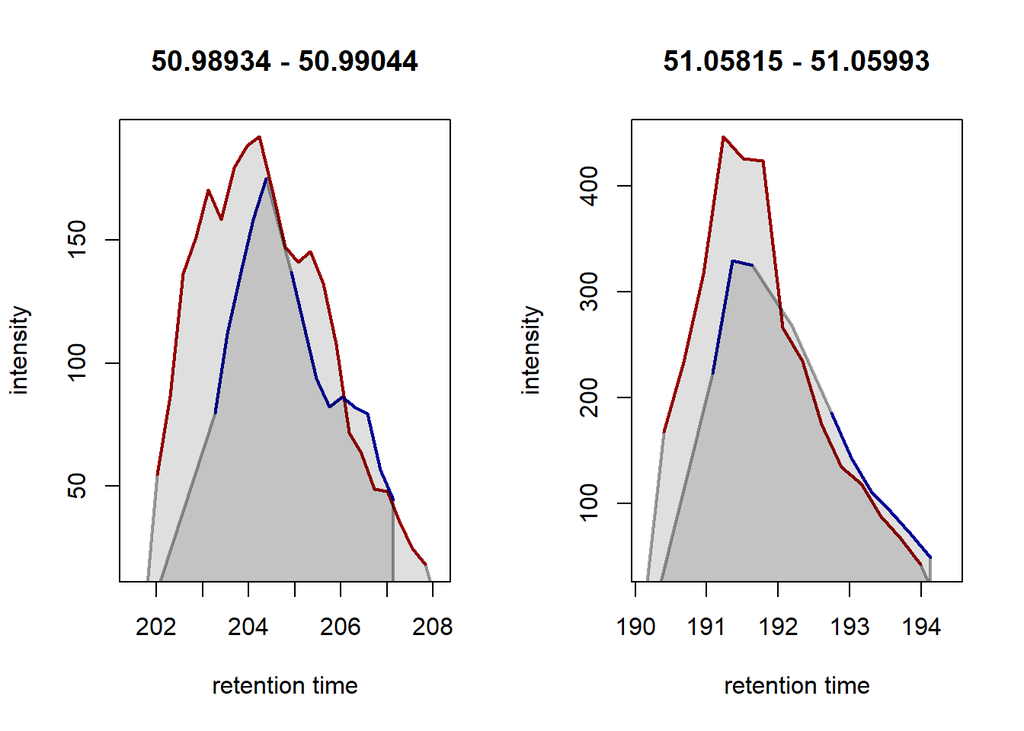

After gap-filling, also in the blue colored sample a chromatographic peak is present and its peak area would be reported as feature abundance for that sample.

To further assess the effectiveness of the gap-filling method for rescuing signals, we can also plot the average of features with at least one missing value against the average filled-in signal. It is advisable to perform this analysis on repeatedly measured samples; in this case, our QC/POOL samples will be used.

For this, we extract:

- Feature values from detected chromatographic peaks by setting `filled = FALSE` in the `featuresValues()` call.
- The filled-in signal by first extracting both detected and gap-filled abundances and then replace the values for detected chromatographic peaks with `NA`.

Then, we calculate the row averages of both of these matrices and plot them against each other.

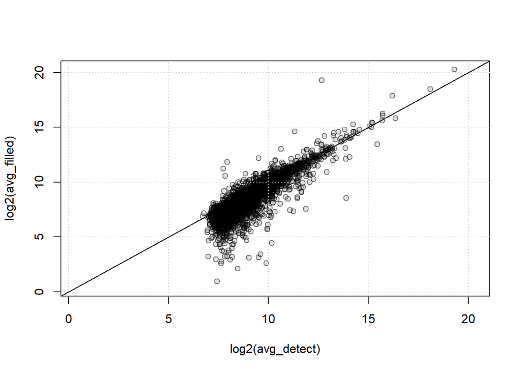

```r
#' Get only detected signal in QC samples
vals_detect <- featureValues(data, filled = FALSE)[, QC_samples]

#' Get detected and filled-in signal
vals_filled <- featureValues(data)[, QC_samples]

#' Replace detected signal with NA
vals_filled[!is.na(vals_detect)] <- NA

#' Identify features with at least one filled peak
has_filled <- is.na(rowSums(vals_detect))

#' Calculate row averages for features with missing values
avg_detect <- rowMeans(vals_detect[has_filled, ], na.rm = TRUE)
avg_filled <- rowMeans(vals_filled[has_filled, ], na.rm = TRUE)

#' Plot the values against each other (in log2 scale)
plot(log2(avg_detect), log2(avg_filled),
     xlim = range(log2(c(avg_detect, avg_filled)), na.rm = TRUE),
     ylim = range(log2(c(avg_detect, avg_filled)), na.rm = TRUE),
     pch = 21, bg = "#00000020", col = "#00000080")
grid()
abline(0, 1)
```

The detected (x-axis) and gap-filled (y-axis) values for QC samples are highly correlated. Especially for higher abundances, the agreement is very high, while for low intensities, as can be expected, differences are higher. Below we in addition fit a linear regression line to the data and summarize its results

```r
#' fit a linear regression line to the data
l <- lm(log2(avg_filled) ~ log2(avg_detect))
summary(l)
```

```
##
## Call:
## lm(formula = log2(avg_filled) ~ log2(avg_detect))
##
## Residuals:
##     Min      1Q  Median      3Q     Max
## -6.8176 -0.3807  0.1725  0.5492  6.7504
##
## Coefficients:
##                  Estimate Std. Error t value Pr(>|t|)
## (Intercept)      -1.62359    0.11545  -14.06   <2e-16 ***
## log2(avg_detect)  1.11763    0.01259   88.75   <2e-16 ***
## ---
## Signif. codes:  0 '***' 0.001 '**' 0.01 '*' 0.05 '.' 0.1 ' ' 1
##
## Residual standard error: 0.9366 on 2846 degrees of freedom
##   (846 observations deleted due to missingness)
## Multiple R-squared:  0.7346, Adjusted R-squared:  0.7345
## F-statistic:  7877 on 1 and 2846 DF,  p-value: < 2.2e-16
```

## Preprocessing results

The final results of the LC-MS data preprocessing are stored within the `XcmsExperiment` object. This includes the identified chromatographic peaks, the alignment results, as well as the correspondence results. In addition, to guarantee reproducibility, this result object keeps track of all performed processing steps, including the individual parameter objects used to configure these. The `processHistory()` function returns a list of the various applied processing steps in chronological order. Below we extract the information for the first step of the performed preprocessing.

```r
#' Check first step of the process history
processHistory(data)[[1]]
```

```
## Object of class "XProcessHistory"
##  type: Peak detection
##  date: Wed May 29 10:03:24 2024
##  info:
##  fileIndex: 1,2,3,4,5,6,7,8,9,10
##  Parameter class: CentWaveParam
##  MS level(s) 1
```

The `processParam()` function could then be used to extract the actual parameter class used to configure this processing step.

The final result of the whole LC-MS data preprocessing would be a two-dimensional matrix with abundances of the so-called LC-MS features in all samples. Note that at this stage of the analysis features are only characterized by their *m/z* and retention time and we don’t have yet any information which metabolite a feature could represent.

As we have seen before, such feature matrix could be extracted with the `featureValues()` function and the corresponding feature characteristics (i.e., their *m/z* and retention time values) using the `featureDefinitions()` function. Thus, these two arrays could be extracted from the *xcms* result object and used/imported in other analysis packages for further processing. They could for example also be exported to tab delimited text files, and used in an external tool, or used, if also MS2 spectra would be available for feature-based molecular networking in the GNPS analysis environment (Nothias et al. 2020) (see also the [GNPS documentation](https://ccms-ucsd.github.io/GNPSDocumentation/featurebasedmolecularnetworking-with-xcms3/) for more information).

For further processing in R, if no reference or link to the raw MS data is required, it is however suggested to extract the *xcms* preprocessing result using the `quantify()` function as a `SummarizedExperiment` object, Bioconductor’s default container for data from biological assays/experiments. This simplifies integration with other Bioconductor analysis packages. The `quantify()` function takes the same parameters than the `featureValues()` function, thus, with the call below we extract a `SummarizedExperiment` with only the detected, but not gap-filled, feature abundances:

```r
#' Extract results as a SummarizedExperiment
res <- quantify(data, method = "sum", filled = FALSE)
res
```

```
## class: SummarizedExperiment
## dim: 9068 10
## metadata(6): '' '' ... '' ''
## assays(1): raw
## rownames(9068): FT0001 FT0002 ... FT9067 FT9068
## rowData names(11): mzmed mzmin ... QC ms_level
## colnames(10): MS_QC_POOL_1_POS.mzML MS_A_POS.mzML ... MS_F_POS.mzML
##   MS_QC_POOL_4_POS.mzML
## colData names(6): mzML_file injection_index ... age spectraOrigin
```

Sample annotations from the *xcms* result’s `sampleData()` are now available as `colData()` (column, sample annotations) and the `featureDefinitions()` as `rowData()` (row, feature annotations). The feature values have been added as the first `assay()` in the `SummarizedExperiment` and even the processing history is available in the object’s `metadata()`. A `SummarizedExperiment` supports multiple assays, all being numeric matrices with the same dimensions. Below we thus add the detected and gap-filled feature abundances as an additional assay to the `SummarizedExperiment`.

```r
assays(res)$raw_filled <- featureValues(data, method = "sum",
                                        filled = TRUE )

#' Different assay in the SummarizedExperiment object
assayNames(res)
```

```
## [1] "raw"        "raw_filled"
```

Feature abundances can be extracted with the `assay()` function. Below we extract the first 6 lines of the detected and gap-filled feature abundances:

```r
assay(res, "raw_filled") |> head()
```

```
##        MS_QC_POOL_1_POS.mzML MS_A_POS.mzML MS_B_POS.mzML MS_QC_POOL_2_POS.mzML
## FT0001              421.6162      689.2422      411.3295              481.7436
## FT0002              710.8078      875.9192      457.5920              693.6997
## FT0003              445.5711      613.4410      277.5022              497.8866
## FT0004            16994.5260    24605.7340    19766.7069            17808.0933
## FT0005             3284.2664     4526.0531     3521.8221             3379.8909
## FT0006            10681.7476    10009.6602     9599.9701            10800.5449
##        MS_C_POS.mzML MS_D_POS.mzML MS_QC_POOL_3_POS.mzML MS_E_POS.mzML
## FT0001      314.7567      635.2732              439.6086      570.5849
## FT0002      781.2416      648.4344              700.9716     1054.0207
## FT0003      425.3774      634.9370              449.0933      556.2544
## FT0004    22780.6683    22873.1061            16965.7762    23432.1252
## FT0005     4396.0762     4317.7734             3270.5290     4533.8667
## FT0006     4792.2390     7296.4262             2382.1788     9236.9799
##        MS_F_POS.mzML MS_QC_POOL_4_POS.mzML
## FT0001      579.9360              437.0340
## FT0002      534.4577              711.0361
## FT0003      461.0465              232.1075
## FT0004    22198.4607            16796.4497
## FT0005     4161.0132             3142.2268
## FT0006     6817.8785             6911.5439
```

An advantage, in addition to being a container for the full preprocessing results is also the possibility of an easy and intuitive creation of data subsets ensuring data integrity. It would for example be very easy to subset the full data to a selection of features and/or samples:

```r
res[1:14, 3:8]
```

```
## class: SummarizedExperiment
## dim: 14 6
## metadata(6): '' '' ... '' ''
## assays(2): raw raw_filled
## rownames(14): FT0001 FT0002 ... FT0013 FT0014
## rowData names(11): mzmed mzmin ... QC ms_level
## colnames(6): MS_B_POS.mzML MS_QC_POOL_2_POS.mzML ...
##   MS_QC_POOL_3_POS.mzML MS_E_POS.mzML
## colData names(6): mzML_file injection_index ... age spectraOrigin
```

The `XcmsExperiment` object can also be saved for later use using the `storeResults()` function. The data can be exported in different formats, to enable also easier integration with non-R-based software. Currently, it is possible to export the data in R-specific *RData* format or as (separate) plain text files. Export to the community developed open mzTab-M format is currently being developed and will be supported in future. Below we export the *xcms* result object with R’s default binary format for object serialization.

```r
#' Save `XcmsExperiment` object
storeResults(data, RDataParam(fileName = "data.RData"))

#' Save `SummarizedExperiment` object
save(res, file = "SumExp.RData")
```

# Data normalization

Generally, for LC-MS data, noise can be categorized into three main groups(Broadhurst et al. 2018):

- Variances introduced by sample collection and initial processing, which can include differences in sample amounts. This type of bias is expected to be sample-specific and affect all signals in a sample in the same way. Methods like median scaling, loess or quantiles normalization can adjust for this bias.
- Signal drifts along measurement of samples from an experiment. Reasons for such drifts can be related to aging of the instrumentation used (columns, detector), but also changes in metabolite abundances/characteristics within the sample, such as oxidation or other modifications of the sample’s metabolites which are expected to affect samples measured later in a sample run more than those measured at the beginning. This bias can play a major role in large experiments measured over a long time range and is usually considered to affect individual metabolites (or metabolite groups) differently. For adjustment, moving average or linear regression-based approaches can be used. The latter can for example be performed using the `adjust_lm()` function from the *MetaboCoreUtils* package.
- Batch-related biases. This comprises any noise that is specific to a larger set of samples, which can be the set of samples measured in one LC-MS measurement run (i.e. from one analysis plate) or samples measured using a specific batch of reagents. This noise is assumed to affect all samples in one batch in the same way and linear modeling-based approaches can be used to adjust for this.

Unwanted variation can arise from various sources and is highly dependent on the experiment. Therefore, data normalization should be chosen carefully based on experimental design, statistical aims, and the balance of accuracy and precision achieved through the use of auxiliary information.

Sample preparation biases could be evaluated using internal standards, depending however also when they were added to the sample mixes during sample processing. Repeated measurements of QC samples (usually a pool of the study samples) on the other hand allows to estimate and correct for LC-MS specific biases. Also, proper planning of an experiment, such as measurement of study samples in random order, can largely avoid biases introduced by most of the above mentioned sources of variance.

In this workflow we present some tools to assess data quality and evaluate need for normalization as well options for normalization. For space reasons we do not provide solutions to adjust for all possible sources of variation.

## Initial quality assessment

A principal component analysis (PCA) is a very helpful tool for an initial, unsupervised, visualization of the data that also provides insights into potential quality issues in the data. In order to apply a PCA to the measured feature abundances, we need however to impute (the still present) missing values. We assume that most of these missing values (after the gap-filling step) represent signal which is below detection limit. In such cases, missing values can be replaced with random values from the uniform distribution sampling numbers from half of smallest measured value to the smallest measured value for a specific feature. The uniform distribution is defined with two parameters (minimum and maximum) and all values between them have an equal probability of being selected.

Below we impute missing values with that approach and add the resulting data matrix as a new *assay* to our result object.

```r
#' Load preprocessing results
## load("SumExp.RData")
## loadResults(RDataParam("data.RData"))

#' Impute missing values using an uniform distribution
na_unidis <- function(z) {
    na <- is.na(z)
    if (any(na)) {
        min = min(z, na.rm = TRUE)
        z[na] <- runif(sum(na), min = min/2, max = min)
    }
    z
}

#' Row-wise impute missing values and add the data as a new assay
tmp <- apply(assay(res, "raw_filled"), MARGIN = 1, na_unidis)
assays(res)$raw_filled_imputed <- t(tmp)
```

### Principal Component Analysis

PCA is a powerful tool to detect biases in the data. It is a dimensionality reduction technique that allows to visualize the data in a lower-dimensional space. In the context of LC-MS data, PCA can be used to look for overall biases in batch, sample, injection index, ect, … It is important to note that PCA is a linear method and might not be able to detect all biases in the data.

Before plotting the PCA, we will log2 transform, center and scale the data. The log2 transformation is applied to stabilize the variance and centering to remove dependency on absolute abundances.

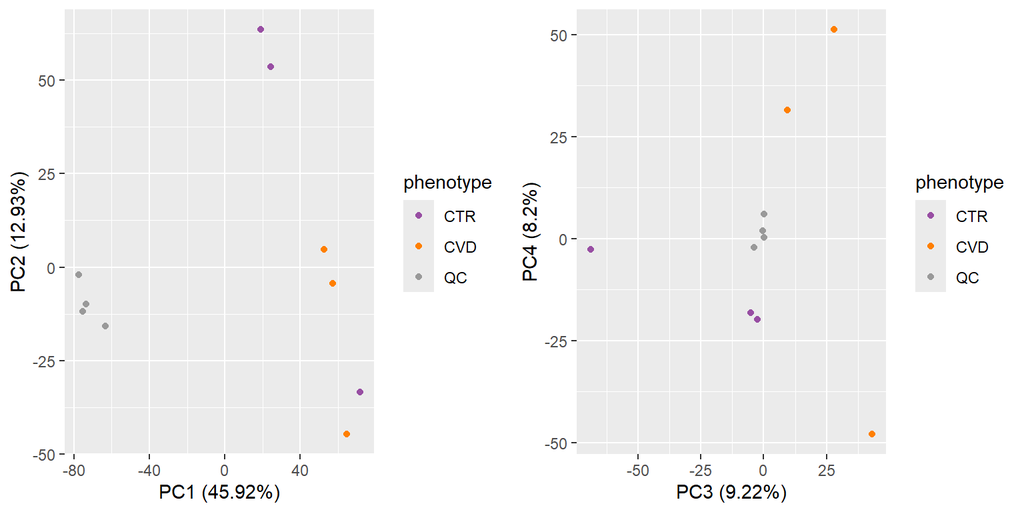

```r
#' Log2 transform and scale data
vals <- assay(res, "raw_filled_imputed") |>
    log2() |>
    t() |>
    scale(center = TRUE, scale = TRUE)

#' Perform the PCA
pca_res <- prcomp(vals, scale = FALSE, center = FALSE)

#' Plot the results
vals_st <- cbind(vals, phenotype = res$phenotype)
pca_12 <- autoplot(pca_res, data = vals_st , colour = 'phenotype', scale = 0) +
    scale_color_manual(values = col_phenotype)
pca_34 <- autoplot(pca_res, data = vals_st, colour = 'phenotype',
                   x = 3, y = 4, scale = 0) +
    scale_color_manual(values = col_phenotype)
grid.arrange(pca_12, pca_34, ncol = 2)
```

The PCA above shows a clear separation of the study samples (plasma) from the QC samples (serum) on the first principal component (PC1). The separation based on phenotype is visible on the third principal component (PC3).

In some cases, it can be a better option to remove the imputed values and evaluate the PCA again. This is especially true if the imputed values are replacing a large proportion of the data.

### Intensity evaluation

Global differences in feature abundances between samples (e.g. due to sample-specific biases) can be evaluated by plotting the distribution of the log2 transformed feature abundances using boxplots of violin plots. Below we show the number of detected chromatographic peaks per sample and the distribution of the log2 transformed feature abundances.

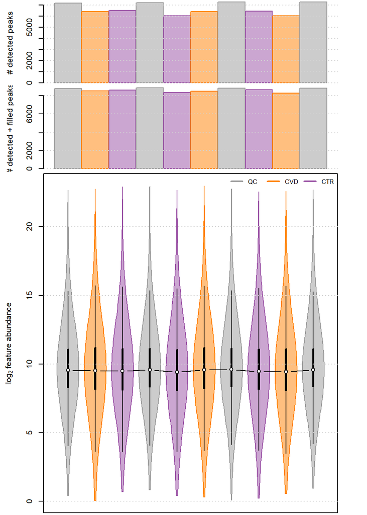

```r
layout(mat = matrix(1:3, ncol = 1), height = c(0.2, 0.2, 0.8))

par(mar = c(0.2, 4.5, 0.2, 3))
barplot(apply(assay(res, "raw"), MARGIN = 2, function(x) sum(!is.na(x))),
        col = paste0(col_sample, 80), border = col_sample,
        ylab = "# detected peaks", xaxt = "n", space = 0.012)
grid(nx = NA, ny = NULL)
barplot(apply(assay(res, "raw_filled"), MARGIN = 2, function(x) sum(!is.na(x))),
        col = paste0(col_sample, 80), border = col_sample,
        ylab = "# detected + filled peaks", xaxt = "n",
        space = 0.012)
grid(nx = NA, ny = NULL)
vioplot(log2(assay(res, "raw_filled")), xaxt = "n",
        ylab = expression(log[2]~feature~abundance),
        col = paste0(col_sample, 80), border = col_sample)
points(colMedians(log2(assay(res, "raw_filled")), na.rm = TRUE), type = "b",
       pch = 1)
grid(nx = NA, ny = NULL)
legend("topright", col = col_phenotype,
       legend = names(col_phenotype), lty=1, lwd = 2, xpd = TRUE, ncol = 3,
       cex = 0.8,  bty = "n")
```

The upper part of the plot show that the gap filling steps allowed to rescue a consequent number of *NAs* and allowed us to have a more equivalent number of feature values per sample. As we assume that every sample should have a similar amount of features detected. Additionally we observe that, on average, the signal distribution from the individual samples is very similar.

An alternative way to evaluate differences in abundances between samples are *relative log abundance* (RLA) plots (De Livera et al. 2012). An RLA value is the abundance of a feature in a sample relative to the median abundance of the same feature across multiple samples. We can discriminate between *within group* and *across group* RLAs, depending whether the abundance is compared against samples within the same sample group or across all samples. Within group RLA assess the tightness of replicate within groups and should have a median close to zero and low variation around it. When used across groups, they allow to compare behavior between groups. Generally, between-sample differences can be easier spotted using RLA plots. Below we calculate and visualize within group RLA values using the `rowRla()` function from the *MsCoreUtils* package defining with parameter `f` the sample groups.

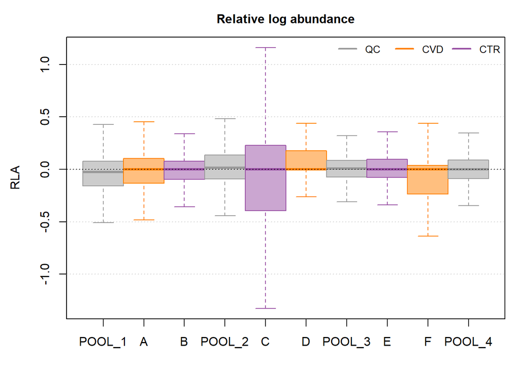

RLA plot for the raw data and filled data. Note: outliers are not drawn.

```r
par(mfrow = c(1, 1), mar = c(3.5, 4.5, 2.5, 1))
boxplot(MsCoreUtils::rowRla(assay(res, "raw_filled"),
                            f = res$phenotype, transform = "log2"),
        cex = 0.5, pch = 16,
        col = paste0(col_sample, 80), ylab = "RLA",
        border = col_sample, boxwex = 1,
        outline = FALSE, xaxt = "n", main = "Relative log abundance",
        cex.main = 1)
axis(side = 1, at = seq_len(ncol(res)), labels = colData(res)$sample_name)
grid(nx = NA, ny = NULL)
abline(h = 0, lty=3, lwd = 1, col = "black")
legend("topright", col = col_phenotype,
       legend = names(col_phenotype), lty=1, lwd = 2, xpd = TRUE, ncol = 3,
       cex = 0.8,  bty = "n")
```

### Internal standard

Depending when internal standards (IS) are added to the sample mixes, they allow evaluation of variances introduced by the subsequent processing and analysis steps. For the present experiment, IS were added to the original plasma samples before sample extraction which included also protein and lipid removal steps. They can therefore be used to evaluate variances introduced by sample extraction and any subsequent steps, can however not be used to infer conclusions on performance or differences on the original sample collection (blood drawing, storage, plasma creation).

We loaded before the *m/z* and expected retention times for the list of 20 IS, now we need to identify features representing signal from these. Thus, we again use the `matchValues()` function from the *MetaboAnnotation* package. With parameters `mzColname` and `rtColname` we specify the column names in the query (our IS) and target (features detected in the data set) that contain the *m/z* and retention time values on which to match entities.

We then filter these *matches* to only keep IS that match with a single feature using the `filterMatches()` function in combination with `SingleMatchParam`.

```r
# Do we keep IS in normalisation ? Does not give much info... Would simplify a bit
#' Creating a column within our IS table
intern_standard$feature_id <- NA_character_

#' Identify features matching m/z and RT of internal standards.
fdef <- featureDefinitions(data)
fdef$feature_id <- rownames(fdef)
match_intern_standard <- matchValues(
    query = intern_standard,
    target = fdef,
    mzColname = c("mz", "mzmed"),
    rtColname = c("RT", "rtmed"),
    param = MzRtParam(ppm = 50, toleranceRt = 10))

#' Keep only matches with a 1:1 mapping standard to feature.
param <- SingleMatchParam(duplicates = "remove", column = "score_rt",
                          decreasing = TRUE)
match_intern_standard <- filterMatches(match_intern_standard, param)

intern_standard$feature_id <- match_intern_standard$target_feature_id
intern_standard <- intern_standard[!is.na(intern_standard$feature_id), ]
```

These internal standards play a crucial role in guiding the normalization process. Given the assumption that the samples were artificially spiked, we possess a known ground truth—that the abundance or intensity of the internal standard should be consistent. Any difference is expected to be due to technical differences/variance. Consequently, normalization aims to minimize variation between samples for the internal standard, reinforcing the reliability of our analyses.

## Between sample normalisation

The previous RLA plot showed that the data had some biases that need to be corrected. Therefore, we will implement between-sample normalization using filled-in features. This process effectively mitigates variations influenced by technical issues, such as differences in sample preparation, processing and injection methods. In this instance, we will employ a commonly used technique known as median scaling (De Livera et al. 2012).

### Median scaling

This method involves computing the median for each sample, followed by determining the median of these individual sample medians. This ensures consistent median values for each sample throughout the entire data set. Maintaining uniformity in the average total metabolite abundance across all samples is crucial for effective implementation.

This process aims to establish a shared baseline for the central tendency of metabolite abundance, mitigating the impact of sample-specific technical variations. This approach fosters a more robust and comparable analysis of the top features across the data set. The assumption is that normalizing based on the median, known for its lower sensitivity to extreme values, enhances the comparability of top features and ensures a consistent average abundance across samples.

```r
#' Compute median and generate normalization factor
mdns <- apply(assay(res, "raw_filled"), MARGIN = 2,
              median, na.rm = TRUE )
nf_mdn <- mdns / median(mdns)

#' divide dataset by median of median and create a new assay.
assays(res)$norm <- sweep(assay(res, "raw_filled"), MARGIN = 2, nf_mdn, '/')
assays(res)$norm_imputed <- sweep(assay(res, "raw_filled_imputed"), MARGIN = 2,
                                  nf_mdn, '/')
```

The median scaling is calculated for both imputed and non-imputed data, with each set stored separately within the `SummarizedExperiment` object. This approach facilitates testing various normalization strategies while maintaining a record of all processing steps undertaken, enabling easy regression to previous stages if necessary.

## Assessing overall effectiveness of the normalization approach

It is crucial to evaluate the effectiveness of the normalization process. This can be achieved by comparing the distribution of the log2 transformed feature abundances before and after normalization. Additionally, the relative log abundance (RLA) plots can be used to assess the tightness of replicates within groups and compare the behavior between groups.

### Principal Component Analysis

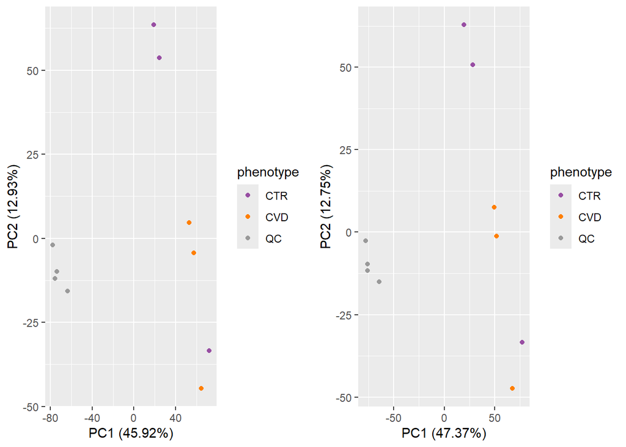

```r
#' Data before
vals_st <- cbind(vals, phenotype = res$phenotype)
pca_raw <- autoplot(pca_res, data = vals_st,
                    colour = 'phenotype', scale = 0) +
    scale_color_manual(values = col_phenotype)

#' Data after
vals_norm <- apply(assay(res, "norm"), MARGIN = 1, na_unidis) |>
    log2() |>
    scale(center = TRUE, scale = TRUE)

pca_res_norm <- prcomp(vals_norm, scale = FALSE, center = FALSE)
vals_st_norm <- cbind(vals_norm, phenotype = res$phenotype)
pca_adj <- autoplot(pca_res_norm, data = vals_st_norm,
                    colour = 'phenotype', scale = 0) +
    scale_color_manual(values = col_phenotype)

grid.arrange(pca_raw, pca_adj, ncol = 2)
```

Normalization did not have a large impact on PC1 or PC2 (see above), but the separation of the study groups on PC3 seems to be better and difference between QC samples lower after normalization (see below).

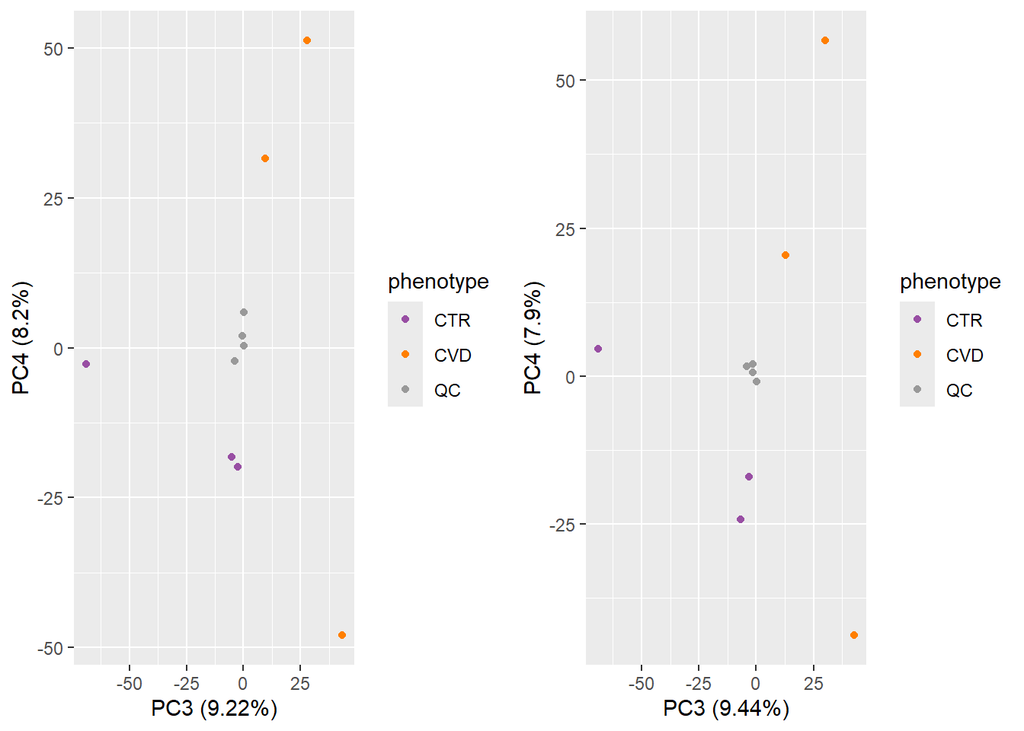

```r
pca_raw <- autoplot(pca_res, data = vals_st ,
                    colour = 'phenotype', x = 3, y = 4, scale = 0) +
    scale_color_manual(values = col_phenotype)
pca_adj <- autoplot(pca_res_norm, data = vals_st_norm,
                    colour = 'phenotype', x = 3, y = 4, scale = 0) +
    scale_color_manual(values = col_phenotype)

grid.arrange(pca_raw, pca_adj, ncol = 2)
```

The PCA plots above show that the normalization process has not changed the overall structure of the data. The separation between the study and QC samples remains the same. This is an expected results as normalization should not correct for biological variance and only technical.

### Intensity evaluation

We compare the RLA plots before and after between-sample normalization to evaluate its impact on the data.

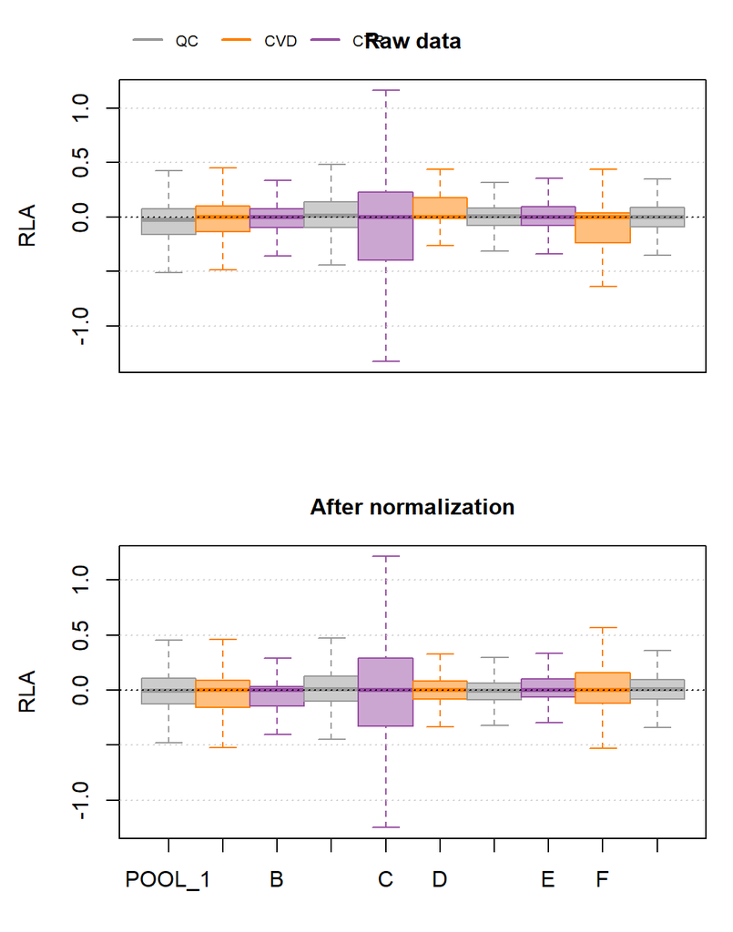

RLA plot before and after normalization. Note: outliers are not drawn.

```r
par(mfrow = c(2, 1), mar = c(3.5, 4.5, 3, 1))

boxplot(rowRla(assay(res, "raw_filled"), group = res$phenotype),
        cex = 0.5, pch = 16, ylab = "RLA", border = col_sample,
        col = paste0(col_sample, 80), cex.main = 1, outline = FALSE,
        xaxt = "n", main = "Raw data", boxwex = 1)
grid(nx = NA, ny = NULL)
legend("topleft", inset = c(0, -0.2), col = col_phenotype,
       legend = names(col_phenotype), lty=1, lwd = 2, xpd = TRUE,
       ncol = 3, cex = 0.7, bty = "n")
abline(h = 0, lty=3, lwd = 1, col = "black")

boxplot(rowRla(assay(res, "norm"), group = res$phenotype),
        cex = 0.5, pch = 16, ylab = "RLA", border = col_sample,
        col = paste0(col_sample, 80), boxwex = 1, outline = FALSE,
        xaxt = "n", main = "After normalization", cex.main = 1)
axis(side = 1, at = seq_len(ncol(res)), labels = res$sample_name)
grid(nx = NA, ny = NULL)
abline(h = 0, lty = 3, lwd = 1, col = "black")
```

The normalization process has effectively centered the data around the median and medians for all samples are now closer to zero.

### Coefficient of variation

We next evaluate the coefficient of variation (CV, also referred to as *relative standard deviation* RSD) for features across samples from either QC or study samples. In QC samples, the CV would represent technical noise, while in study samples it would include in addition also expected biological differences. Thus, normalization should reduce the CV in QC samples, while only slightly reducing the CV in study samples. The CV (RSD) is calculated below using the `rowRsd()` function from the *MetaboCoreUtils* package. By setting `mad = TRUE` we use a more robust calculation using the median absolute deviation instead of the standard deviation.

```r
index_study <- res$phenotype %in% c("CTR", "CVD")
index_QC <- res$phenotype == "QC"

sample_res <- cbind(
    QC_raw = rowRsd(assay(res, "raw_filled")[, index_QC],
                    na.rm = TRUE, mad = TRUE),
    QC_norm = rowRsd(assay(res, "norm")[, index_QC],
                     na.rm = TRUE, mad = TRUE),
    Study_raw = rowRsd(assay(res, "raw_filled")[, index_study],
                       na.rm = TRUE, mad = TRUE),
    Study_norm = rowRsd(assay(res, "norm")[, index_study],
                        na.rm = TRUE, mad = TRUE)
)

#' Summarize the values across features
res_df <- data.frame(
    QC_raw = quantile(sample_res[, "QC_raw"], na.rm = TRUE),
    QC_norm = quantile(sample_res[, "QC_norm"], na.rm = TRUE),
    Study_raw = quantile(sample_res[, "Study_raw"], na.rm = TRUE),
    Study_norm = quantile(sample_res[, "Study_norm"], na.rm = TRUE)
)

cpt <- paste0("Table 6.Distribution of RSD values across samples for the raw and ",
              "normalized data.")
pandoc.table(res_df, style = "rmarkdown", caption = cpt)
```

Table 6.Distribution of RSD values across samples for the raw and normalized data.

|  | QC_raw | QC_norm | Study_raw | Study_norm |
| --- | --- | --- | --- | --- |
| **0%** | 0 | 0 | 0 | 0 |
| **25%** | 0.04557 | 0.0451 | 0.1363 | 0.1373 |
| **50%** | 0.09758 | 0.09715 | 0.2635 | 0.2622 |
| **75%** | 0.2003 | 0.1987 | 0.4859 | 0.4824 |
| **100%** | 1.464 | 1.464 | 1.483 | 1.483 |

The table above shows the distribution of the coefficient of variation (CV, RSD) for both raw and normalized data. As anticipated, the CV values for the quality controls (QCs), which reflect technical variance, are lower compared to those for the study samples, which include both technical and biological variance. Overall, minimal disparity exists between the raw and normalized data, which is a positive indication that the normalization process has not introduced bias into the dataset, but also reflects the little differences in average abundances between sample in the raw data.

```r
save(data, file = "data_afternorm.RData")
save(res, file = "SumExp_afternorm.RData")
```

### Conclusion on normalization

The overall conclusion of the normalization process is that very little variance was present from the beginning, normalization was however was able to center the data around the median (as shown by the RLA plot). Given the simplicity and limited size of our example dataset, we will conclude the normalization process at this stage. For more intricate datasets with diverse biases, a tailored approach would be devised. This could include also approaches to adjust for signal drifts or batch effects. One possible option would be to use a linear-model based approach such as can for example be applied with the `adjust_lm()` function from the *MetaboCoreUtils* package.

# Quality control: Feature prefiltering

After normalizing our data we can now pre-filter to clean the data before performing any statistical analysis. In general, pre-filtering of samples and features is performed to remove outliers.

Below we copy the original result object to also keep the unfiltered data for later comparisons.

```r
load("SumExp_afternorm.RData")
load("data_afternorm.RData")

#' Number of features before filtering
nrow(res)
```

```
## [1] 9068
```

```r
#' keep unfiltered object
res_unfilt <- res
```

Here we will eliminate features that exhibit high variability in our dataset. Repeatedly measured QC samples typically serve as a robust basis for cleansing datasets allowing to identify features with excessively high noise. In our data set external QC samples were used, i.e. pooled samples from a different collection and using a slightly different sample matrix, their utility for filtering is somewhat limited. For a comprehensive description and guidelines for data filtering in untargeted metabolomic studies, please refer to (Broadhurst et al. 2018).

We first restrict the data set to features for which a chromatographic peak was detected in at least 2/3 of samples of at least one of the study samples groups. This ensures the statistical tests performed later on the study samples being performed on *reliable* signal. Also, with this filter we remove features that were mostly detected in QC samples, but not the study samples. Such filter can be performed with `filterFeatures()` function from the *xcms* package with the `PercentMissingFilter` setting. Parameter `threshold` of this filter defines the maximal acceptable percentage of samples with missing value(s) in at least one of the sample groups defined by parameter `f`. To consider detected chromatographic peaks per sample, we apply the filter on the `"raw"` assay of our result object, that contains abundance values only for detected chromatographic peaks (prior gap-filling). By replacing the `"QC"` sample group with `NA` in parameter `f` we exclude the QC samples from the evaluation and consider only the study samples. With `threshold = 40` we keep only features for which a peak was detected in 2 out of the 3 samples in one of the sample groups.

```r
#' Limit features to those with at least two detected peaks in one study group.
#' Setting the value for QC samples to NA excludes QC samples from the
#' calculation.
f <- res$phenotype
f[f == "QC"] <- NA
f <- as.factor(f)
res <- filterFeatures(res, PercentMissingFilter(f = f, threshold = 40),
                      assay = "raw")
```

Following the guidelines stated above we decided to still use the QC samples for pre-filtering, on the basis that they represent similar bio-fluids to our study samples, and thus, we anticipate observing relatively similar metabolites affected by similar measurement biases.

We therefore evaluate the *dispersion ratio* (Dratio) (Broadhurst et al. 2018) for all features in the data set. Using the same function as above but this time with the `DratioFilter` parameter. More filter exist for this function and we invite the user to explore them as to decide what is best for their dataset.

```r
#' Compute and filter based on the Dratio
filter_dratio <- DratioFilter(threshold = 0.4,
                              qcIndex = res$phenotype == "QC",
                              studyIndex = res$phenotype != "QC",
                              mad = TRUE)
res <- filterFeatures(res, filter = filter_dratio, assay = "norm_imputed")

#' try using using the norm (filled) and see tht would be better.

#' Phili: i think you advised that we used the dratio filter only, but i am
#'struggling to justify it in a proper way below, as we do expect a high degree
#' of variability between the QC and study samples in any case...
#' jo: I would also be OK to use in addition the RsdFilter - as long as we
#' identify significant features later and can "annotate" some of them.
```

The Dratio filter is a powerful tool to identify features that exhibit high variability in the data, relating the variance observed in QC samples with that in study samples. By setting a threshold of 0.4, we remove features that have a high degree of variability between the QC and study samples. This filtering step ensures that only features are retained that have considerably lower technical than biological variance.

Note that the `rowDratio()` and `rowRsd()` functions from the *MetaboCoreUtils* package could be used to calculate the actual numeric values for the estimates used for filtering, to e.g. to evaluate their distribution in the whole data set or identify data set dependent threshold values.

Finally, we will evaluate the number of features left after the filtering steps and calculate the percentage of features that were removed.

```r
#' Number of features after analysis
nrow(res)
```

```
## [1] 4287
```

```r
#' Percentage left: end/beginning
nrow(res)/nrow(res_unfilt) * 100
```

```
## [1] 47.27614
```

The dataset has been reduced from 9068 to 4287 features. We did remove a considerable amount of features but this is expected as we want to focus on the most reliable features for our analysis. For the rest of our analysis we need to separate the QC samples from the study samples. We will store the QC samples in a separate object for later use.

```r
res_qc <- res[, res$phenotype == "QC"]
res <- res[, res$phenotype != "QC"]
```

We in addition calculate the CV of the QC samples and add that as an additional column to the `rowData()` of our result object. These could be used later to prioritize identified *significant* features with e.g. low technical noise.

```r
#' Calculate the QC's CV and add as feature variable to the data set
rowData(res)$qc_cv <- assay(res_qc, "norm") |>
               rowRsd()
```

Now our data set has been preprocessed, normalized and filtered we can now start to evaluate the distribution of the data and estimate the variation due to biology.